# 1. Setting Environment

### 데이터 크기

```python
data3.info()
```

```
<class 'pandas.core.frame.DataFrame'>
RangeIndex: 8051172 entries, 0 to 8051171
Data columns (total 3 columns):
KWD_NM        object
SESS_DT       int64
SEARCH_CNT    object
dtypes: int64(1), object(2)
memory usage: 184.3+ MB
```

### 형변환 하기(SESS_DT > datetime으로 바꿀 것, SEARCH_CNT > int64로 바꿀 것)

```python
data3
```

[output not shown]

```python
data3.SESS_DT = pd.to_datetime(data3.SESS_DT,format="%Y%m%d")
```

```python
data3.loc[:,'Month'] = data3.SESS_DT.dt.month
```

```python
data3.loc[:,'Weekday']=data3.SESS_DT.dt.weekday
```

```python
data3.SEARCH_CNT = data3.SEARCH_CNT.apply(lambda x:x.replace(',','')) #,때문에 int로 못받음. comma 없앴다.
```

```python
data3.SEARCH_CNT = data3.SEARCH_CNT.astype('int64')
```

```python
data3.info()
```

```
<class 'pandas.core.frame.DataFrame'>
RangeIndex: 8051172 entries, 0 to 8051171
Data columns (total 5 columns):
KWD_NM        object
SESS_DT       datetime64[ns]
SEARCH_CNT    int64
Month         int64
Weekday       int64
dtypes: datetime64[ns](1), int64(3), object(1)
memory usage: 307.1+ MB
```

### 데이터 기본탐색

```python
data3.info()
```

```
<class 'pandas.core.frame.DataFrame'>
RangeIndex: 8051172 entries, 0 to 8051171
Data columns (total 5 columns):
KWD_NM        object
SESS_DT       datetime64[ns]
SEARCH_CNT    int64
Month         int64
Weekday       int64
dtypes: datetime64[ns](1), int64(3), object(1)
memory usage: 307.1+ MB
```

```python
data3.describe()
```

|  | SEARCH_CNT | Month | Weekday |
| --- | --- | --- | --- |
| count | 8.051172e+06 | 8.051172e+06 | 8.051172e+06 |
| mean | 8.352887e+00 | 6.459598e+00 | 2.973742e+00 |
| std | 2.935993e+01 | 1.693706e+00 | 2.019523e+00 |
| min | 1.000000e+00 | 4.000000e+00 | 0.000000e+00 |
| 25% | 1.000000e+00 | 5.000000e+00 | 1.000000e+00 |
| 50% | 3.000000e+00 | 6.000000e+00 | 3.000000e+00 |
| 75% | 6.000000e+00 | 8.000000e+00 | 5.000000e+00 |
| max | 5.043000e+03 | 9.000000e+00 | 6.000000e+00 |

```python
data3.head(5)
```

|  | KWD_NM | SESS_DT | SEARCH_CNT | Month | Weekday |
| --- | --- | --- | --- | --- | --- |
| 0 | 닥스원피스 | 2018-04-07 | 8 | 4 | 5 |
| 1 | 닥터지 브라이트닝 | 2018-04-07 | 1 | 4 | 5 |
| 2 | 달팡 인트랄 | 2018-04-07 | 2 | 4 | 5 |
| 3 | 대상트 | 2018-04-07 | 1 | 4 | 5 |
| 4 | 더블유닷 | 2018-04-07 | 6 | 4 | 5 |

```python
data3.tail(5)
```

|  | KWD_NM | SESS_DT | SEARCH_CNT | Month | Weekday |
| --- | --- | --- | --- | --- | --- |
| 8051167 | stl수영복 | 2018-09-12 | 3 | 9 | 2 |
| 8051168 | supreme | 2018-09-12 | 2 | 9 | 2 |
| 8051169 | tsdjpi82010 | 2018-09-12 | 17 | 9 | 2 |
| 8051170 | zen정장 | 2018-09-12 | 12 | 9 | 2 |
| 8051171 | 가죽 슬립온 | 2018-09-12 | 1 | 9 | 2 |

```python
data3.sample(5)
```

|  | KWD_NM | SESS_DT | SEARCH_CNT | Month | Weekday |
| --- | --- | --- | --- | --- | --- |
| 6824662 | 아동여름운동화 | 2018-06-04 | 14 | 6 | 0 |
| 1589386 | 에블린브라 | 2018-05-17 | 13 | 5 | 3 |
| 3614708 | 여성 장화 | 2018-05-23 | 7 | 5 | 2 |
| 6477578 | 여자 트레이닝 세트 | 2018-07-01 | 2 | 7 | 6 |
| 3822792 | 온앤온 블라우스 | 2018-04-09 | 76 | 4 | 0 |

### 중복값이 있는가?

```python
data3[data3.duplicated() ==True] #없다.
```

|  | KWD_NM | SESS_DT | SEARCH_CNT | Month | Weekday |
| --- | --- | --- | --- | --- | --- |

### NA값이 있는가(column 별로 보기!)

```python
data3[data3.KWD_NM.isnull()==True]
```

|  | KWD_NM | SESS_DT | SEARCH_CNT | Month | Weekday |
| --- | --- | --- | --- | --- | --- |

```python
data3[data3.SESS_DT.isnull()==True]
```

|  | KWD_NM | SESS_DT | SEARCH_CNT | Month | Weekday |
| --- | --- | --- | --- | --- | --- |

```python
data3[data3.SEARCH_CNT.isnull()==True]
```

|  | KWD_NM | SESS_DT | SEARCH_CNT | Month | Weekday |
| --- | --- | --- | --- | --- | --- |

```python
data3[data3.Month.isnull()==True]
```

|  | KWD_NM | SESS_DT | SEARCH_CNT | Month | Weekday |
| --- | --- | --- | --- | --- | --- |

```python
data3[data3.Weekday.isnull()==True]
```

|  | KWD_NM | SESS_DT | SEARCH_CNT | Month | Weekday |
| --- | --- | --- | --- | --- | --- |

```python
Search2 = data3
```

```python
del(data3)
```

### 2.4 data4

```python
data4 = pd.read_csv('제5회 Big Data Competition-분석용데이터-04.Custom.csv',engine='python',encoding='utf-8')
```

```python
data4.reset_index(level=0,inplace=True,col_level=0) #2번하기
```

```python
data4.columns = ['CLNT_GENDER','CLNT_ID','CLNT_AGE']
```

```python
data4
```

|  | CLNT_GENDER | CLNT_ID | CLNT_AGE |
| --- | --- | --- | --- |
| 0 | F | 4830726 | 30 |
| 1 | F | 4830874 | 40 |
| 2 | F | 4830975 | 30 |
| 3 | F | 4831275 | 30 |
| 4 | F | 4825325 | 30 |
| 5 | F | 4825382 | 40 |
| 6 | F | 4825797 | 40 |
| 7 | F | 4825908 | 30 |
| 8 | F | 4825961 | 30 |
| 9 | M | 4840532 | 40 |
| 10 | F | 4840825 | 10 |
| 11 | F | 4843304 | 30 |
| 12 | F | 4843591 | 30 |
| 13 | F | 4843997 | 30 |
| 14 | F | 4846369 | 30 |
| 15 | F | 4846380 | 20 |
| 16 | M | 4846440 | 40 |
| 17 | M | 4846511 | 40 |
| 18 | F | 4846738 | 20 |
| 19 | F | 4846869 | 30 |
| 20 | F | 4847147 | 20 |
| 21 | F | 4839353 | 30 |
| 22 | F | 4839427 | 30 |
| 23 | F | 4839489 | 40 |
| 24 | F | 4839742 | 30 |
| 25 | F | 4839795 | 40 |
| 26 | F | 4839826 | 40 |
| 27 | M | 4849242 | 20 |
| 28 | F | 4849302 | 30 |
| 29 | F | 4841127 | 20 |
| ... | ... | ... | ... |
| 671649 | F | 3716232 | 20 |
| 671650 | F | 3718878 | 30 |
| 671651 | F | 3719043 | 20 |
| 671652 | F | 3719284 | 30 |
| 671653 | F | 3719450 | 20 |
| 671654 | F | 3719557 | 30 |
| 671655 | F | 3722059 | 40 |
| 671656 | F | 3722149 | 30 |
| 671657 | F | 3722238 | 30 |
| 671658 | F | 3722352 | 40 |
| 671659 | F | 3724381 | 30 |
| 671660 | F | 3724753 | 30 |
| 671661 | M | 3724812 | 20 |
| 671662 | F | 3724842 | 20 |
| 671663 | F | 3717101 | 40 |
| 671664 | F | 3720346 | 30 |
| 671665 | F | 3720349 | 30 |
| 671666 | F | 3720442 | 20 |
| 671667 | M | 3720555 | 40 |
| 671668 | F | 3722969 | 40 |
| 671669 | F | 3723092 | 30 |
| 671670 | F | 3723190 | 30 |
| 671671 | F | 3723318 | 40 |
| 671672 | F | 3723497 | 40 |
| 671673 | F | 3725195 | 30 |
| 671674 | F | 3725302 | 40 |
| 671675 | M | 3725462 | 40 |
| 671676 | F | 3725818 | 30 |
| 671677 | F | 3661812 | 30 |
| 671678 | M | 3661917 | 40 |

671679 rows × 3 columns

### 데이터 크기

```python
data4.info()
```

```
<class 'pandas.core.frame.DataFrame'>
RangeIndex: 671679 entries, 0 to 671678
Data columns (total 3 columns):
CLNT_GENDER    671679 non-null object
CLNT_ID        671679 non-null int64
CLNT_AGE       671679 non-null int64
dtypes: int64(2), object(1)
memory usage: 15.4+ MB
```

### 형변환 해주자!(CLNT_ID > object로 바꿀 것)

```python
data4.CLNT_ID = data4.CLNT_ID.astype(str)
```

```python
data4.info()
```

```
<class 'pandas.core.frame.DataFrame'>
RangeIndex: 671679 entries, 0 to 671678
Data columns (total 3 columns):
CLNT_GENDER    671679 non-null object
CLNT_ID        671679 non-null object
CLNT_AGE       671679 non-null int64
dtypes: int64(1), object(2)
memory usage: 15.4+ MB
```

### 데이터 기본 탐색

```python
data4.info()
```

```
<class 'pandas.core.frame.DataFrame'>
RangeIndex: 671679 entries, 0 to 671678
Data columns (total 3 columns):
CLNT_GENDER    671679 non-null object
CLNT_ID        671679 non-null object
CLNT_AGE       671679 non-null int64
dtypes: int64(1), object(2)
memory usage: 15.4+ MB
```

```python
data4.describe()
```

|  | CLNT_AGE |
| --- | --- |
| count | 671679.000000 |
| mean | 33.064946 |
| std | 8.380882 |
| min | 10.000000 |
| 25% | 30.000000 |
| 50% | 30.000000 |
| 75% | 40.000000 |
| max | 80.000000 |

```python
data4.head(5)
```

|  | CLNT_GENDER | CLNT_ID | CLNT_AGE |
| --- | --- | --- | --- |
| 0 | F | 4830726 | 30 |
| 1 | F | 4830874 | 40 |
| 2 | F | 4830975 | 30 |
| 3 | F | 4831275 | 30 |
| 4 | F | 4825325 | 30 |

```python
data4.tail(5)
```

|  | CLNT_GENDER | CLNT_ID | CLNT_AGE |
| --- | --- | --- | --- |
| 671674 | F | 3725302 | 40 |
| 671675 | M | 3725462 | 40 |
| 671676 | F | 3725818 | 30 |
| 671677 | F | 3661812 | 30 |
| 671678 | M | 3661917 | 40 |

```python
data4.sample(5)
```

|  | CLNT_GENDER | CLNT_ID | CLNT_AGE |
| --- | --- | --- | --- |
| 147451 | F | 3776046 | 30 |
| 517335 | F | 3660746 | 40 |
| 609603 | M | 5928739 | 30 |
| 445037 | M | 4516137 | 50 |
| 266446 | F | 2427925 | 40 |

### 중복값이 있는가?

```python
data4[data4.duplicated()==True] #없다.
```

|  | CLNT_GENDER | CLNT_ID | CLNT_AGE |
| --- | --- | --- | --- |

### NA값이 있는가?

```python
data4[data4.CLNT_GENDER.isnull()==True]
```

|  | CLNT_GENDER | CLNT_ID | CLNT_AGE |
| --- | --- | --- | --- |

```python
data4[data4.CLNT_ID.isnull()==True]
```

|  | CLNT_GENDER | CLNT_ID | CLNT_AGE |
| --- | --- | --- | --- |

```python
data4[data4.CLNT_AGE.isnull()==True]
```

|  | CLNT_GENDER | CLNT_ID | CLNT_AGE |
| --- | --- | --- | --- |

```python
Custom = data4
```

```python
del(data4)
```

### 2.5 data5

```python
data5 = pd.read_csv('제5회 Big Data Competition-분석용데이터-05.Session.csv',engine='python',encoding='utf-8')
```

```python
data5.reset_index(level=None,inplace=True)
```

```python
data5.columns=['CLNT_ID','SESS_ID','SESS_SEQ','SESS_DT','TOT_PAG_VIEW_CT','TOT_SESS_HR_V','DVC_CTG_NM','ZON_NM','CITY_NM']
```

### 데이터 크기

```python
data5.info()
```

```
<class 'pandas.core.frame.DataFrame'>
RangeIndex: 2712907 entries, 0 to 2712906
Data columns (total 9 columns):
CLNT_ID            int64
SESS_ID            int64
SESS_SEQ           int64
SESS_DT            int64
TOT_PAG_VIEW_CT    float64
TOT_SESS_HR_V      object
DVC_CTG_NM         object
ZON_NM             object
CITY_NM            object
dtypes: float64(1), int64(4), object(4)
memory usage: 186.3+ MB
```

### 형변환 해주자! (CLNT_ID, SESS_ID > object, SESS_DT > datetime, TOT_PAG_VIEW_CT, TOT_SESS_HR_V > int64)

```python
data5.CLNT_ID = data5.CLNT_ID.astype(str)
```

```python
data5.SESS_ID = data5.SESS_ID.astype(str)
```

```python
data5.SESS_DT = pd.to_datetime(data5.SESS_DT,format="%Y%m%d")
```

```python
data5.loc[:,'Month'] = data5.SESS_DT.dt.month
```

```python
data5.loc[:,'Weekday'] = data5.SESS_DT.dt.weekday
```

```python
data5[data5.TOT_PAG_VIEW_CT.isnull()==True]
```

|  | CLNT_ID | SESS_ID | SESS_SEQ | SESS_DT | TOT_PAG_VIEW_CT | TOT_SESS_HR_V | DVC_CTG_NM | ZON_NM | CITY_NM | Month | Weekday |
| --- | --- | --- | --- | --- | --- | --- | --- | --- | --- | --- | --- |
| 11409 | 5075856 | 6836578 | 19 | 2018-06-08 | NaN | NaN | mobile | Seoul | Seoul | 6 | 4 |
| 26628 | 5368135 | 4391880 | 10 | 2018-07-18 | NaN | NaN | mobile | Chungcheongnam-do | Yeongi-gun | 7 | 2 |
| 43241 | 5687186 | 852560 | 40 | 2018-09-16 | NaN | NaN | mobile | Seoul | Seoul | 9 | 6 |
| 58494 | 6104032 | 1568619 | 78 | 2018-09-04 | NaN | NaN | mobile | Chungcheongnam-do | Cheonan-si | 9 | 1 |
| 64700 | 3735745 | 6884635 | 1 | 2018-06-07 | NaN | NaN | desktop | Gwangju | Gwangju | 6 | 3 |
| 67340 | 401333 | 3950587 | 5 | 2018-07-25 | NaN | 1,583 | mobile | Seoul | Seoul | 7 | 2 |
| 72888 | 685173 | 6608500 | 16 | 2018-06-12 | NaN | NaN | mobile | Jeollanam-do | Yeosu-si | 6 | 1 |
| 78579 | 5360178 | 8534075 | 191 | 2018-05-11 | NaN | NaN | mobile | Gyeonggi-do | Goyang-si | 5 | 4 |
| 80904 | 5089253 | 2852934 | 24 | 2018-08-13 | NaN | NaN | mobile | Seoul | Seoul | 8 | 0 |
| 91070 | 887809 | 6282443 | 49 | 2018-06-17 | NaN | NaN | mobile | Daegu | Daegu | 6 | 6 |
| 107900 | 124859 | 1543135 | 9 | 2018-09-05 | NaN | NaN | mobile | Gyeonggi-do | Gimpo-si | 9 | 2 |
| 112413 | 3964085 | 6861843 | 42 | 2018-06-08 | NaN | NaN | mobile | Seoul | Seoul | 6 | 4 |
| 115617 | 1937442 | 7350667 | 4 | 2018-05-30 | NaN | NaN | mobile | Seoul | Seoul | 5 | 2 |
| 120189 | 4533466 | 8924428 | 5 | 2018-05-04 | NaN | NaN | mobile | Daegu | Daegu | 5 | 4 |
| 143093 | 9890 | 7052949 | 31 | 2018-06-04 | NaN | NaN | mobile | Seoul | Seoul | 6 | 0 |
| 149596 | 1673247 | 7122433 | 1 | 2018-06-03 | NaN | NaN | desktop | Daegu | Daegu | 6 | 6 |
| 156854 | 6090954 | 1025865 | 64 | 2018-09-13 | NaN | NaN | mobile | Seoul | Seoul | 9 | 3 |
| 158528 | 859658 | 8071269 | 23 | 2018-05-18 | NaN | NaN | mobile | Gyeongsangnam-do | Yangsan-si | 5 | 4 |
| 172397 | 5628 | 388082 | 30 | 2018-09-24 | NaN | NaN | mobile | Seoul | Seoul | 9 | 0 |
| 178923 | 1165396 | 8536467 | 54 | 2018-05-11 | NaN | NaN | mobile | Gyeonggi-do | Gimpo-si | 5 | 4 |
| 179358 | 1414648 | 4081483 | 321 | 2018-07-23 | NaN | NaN | mobile | Seoul | Seoul | 7 | 0 |
| 190527 | 4864135 | 3840635 | 35 | 2018-07-27 | NaN | NaN | mobile | Seoul | Seoul | 7 | 4 |
| 190529 | 4864135 | 3849609 | 33 | 2018-07-27 | NaN | NaN | mobile | Incheon | Incheon | 7 | 4 |
| 217104 | 406508 | 7114118 | 14 | 2018-06-03 | NaN | NaN | mobile | Busan | Busan | 6 | 6 |
| 232444 | 58842 | 2574753 | 21 | 2018-08-18 | NaN | NaN | mobile | Jeollabuk-do | Jeonju-si | 8 | 5 |
| 248675 | 5085285 | 7630020 | 9 | 2018-05-26 | NaN | NaN | mobile | Gyeonggi-do | Suwon-si | 5 | 5 |
| 254980 | 645598 | 8760156 | 3 | 2018-05-07 | NaN | NaN | mobile | Seoul | Seoul | 5 | 0 |
| 255342 | 5117190 | 4521786 | 27 | 2018-07-16 | NaN | NaN | mobile | Chungcheongnam-do | Asan-si | 7 | 0 |
| 256727 | 262574 | 9142780 | 140 | 2018-05-01 | NaN | NaN | mobile | Busan | Busan | 5 | 1 |
| 260380 | 1967210 | 5715295 | 10 | 2018-06-26 | NaN | NaN | mobile | Jeju-do | Jeju-si | 6 | 1 |
| ... | ... | ... | ... | ... | ... | ... | ... | ... | ... | ... | ... |
| 2443049 | 2774674 | 8278988 | 12 | 2018-05-15 | NaN | NaN | mobile | Gyeonggi-do | Bucheon-si | 5 | 1 |
| 2443050 | 2774674 | 8291841 | 8 | 2018-05-15 | NaN | NaN | mobile | Gyeonggi-do | Bucheon-si | 5 | 1 |
| 2443051 | 2774674 | 8288339 | 10 | 2018-05-15 | NaN | NaN | mobile | Gyeonggi-do | Bucheon-si | 5 | 1 |
| 2443052 | 2774674 | 8243940 | 14 | 2018-05-16 | NaN | NaN | mobile | Gyeonggi-do | Bucheon-si | 5 | 2 |
| 2443053 | 2774674 | 8146947 | 20 | 2018-05-17 | NaN | NaN | mobile | Daejeon | Daejeon | 5 | 3 |
| 2459246 | 1103207 | 9110870 | 20 | 2018-05-01 | NaN | NaN | mobile | Seoul | Seoul | 5 | 1 |
| 2481980 | 3162306 | 7225372 | 271 | 2018-06-02 | NaN | NaN | mobile | Chungcheongnam-do | Cheonan-si | 6 | 5 |
| 2487340 | 4030609 | 9564596 | 89 | 2018-04-24 | NaN | NaN | mobile | Seoul | Seoul | 4 | 1 |
| 2493941 | 4841239 | 6744849 | 1 | 2018-06-09 | NaN | NaN | desktop | Daejeon | Daejeon | 6 | 5 |
| 2535077 | 4482800 | 4965457 | 11 | 2018-07-09 | NaN | NaN | mobile | Seoul | Seoul | 7 | 0 |
| 2549218 | 6295526 | 10884786 | 232 | 2018-04-02 | NaN | NaN | mobile | Seoul | Seoul | 4 | 0 |
| 2555487 | 5612103 | 7419650 | 27 | 2018-05-29 | NaN | NaN | mobile | Seoul | Seoul | 5 | 1 |
| 2559039 | 4652838 | 9479610 | 17 | 2018-04-25 | NaN | NaN | mobile | Seoul | Seoul | 4 | 2 |
| 2572457 | 4499041 | 9564396 | 10 | 2018-04-24 | NaN | NaN | mobile | Gyeonggi-do | Yongin-si | 4 | 1 |
| 2585682 | 4795289 | 9606812 | 8 | 2018-04-23 | NaN | NaN | mobile | Busan | Busan | 4 | 0 |
| 2591845 | 5689529 | 8526388 | 10 | 2018-05-11 | NaN | NaN | mobile | Seoul | Seoul | 5 | 4 |
| 2597221 | 4076418 | 8476400 | 22 | 2018-05-12 | NaN | NaN | mobile | Daejeon | Daejeon | 5 | 5 |
| 2597223 | 4076418 | 8471136 | 24 | 2018-05-12 | NaN | NaN | mobile | Daejeon | Daejeon | 5 | 5 |
| 2613801 | 4179979 | 8405106 | 58 | 2018-05-13 | NaN | NaN | mobile | Chungcheongnam-do | Asan-si | 5 | 6 |
| 2616297 | 3866268 | 1181458 | 1 | 2018-09-11 | NaN | NaN | desktop | Seoul | Seoul | 9 | 1 |
| 2631341 | 4151697 | 10458795 | 8 | 2018-04-09 | NaN | NaN | mobile | Seoul | Seoul | 4 | 0 |
| 2631342 | 4151697 | 10886395 | 6 | 2018-04-02 | NaN | NaN | mobile | Gyeongsangbuk-do | Chilgok-gun | 4 | 0 |
| 2686641 | 2553487 | 1510814 | 1 | 2018-09-05 | NaN | NaN | desktop | Gyeonggi-do | Hwaseong-si | 9 | 2 |
| 2690902 | 5949974 | 9066789 | 25 | 2018-05-02 | NaN | NaN | mobile | Seoul | Seoul | 5 | 2 |
| 2694625 | 5222026 | 10695653 | 24 | 2018-04-05 | NaN | NaN | mobile | Daejeon | Daejeon | 4 | 3 |
| 2694819 | 5945452 | 4805081 | 8 | 2018-07-11 | NaN | NaN | mobile | Incheon | Incheon | 7 | 2 |
| 2695383 | 5317093 | 6650554 | 3 | 2018-06-11 | NaN | NaN | mobile | Gyeonggi-do | Goyang-si | 6 | 0 |
| 2699131 | 6042348 | 8834971 | 24 | 2018-05-06 | NaN | NaN | mobile | Seoul | Seoul | 5 | 6 |
| 2706558 | 5987591 | 4867294 | 111 | 2018-07-10 | NaN | NaN | mobile | Chungcheongnam-do | Yeongi-gun | 7 | 1 |
| 2710234 | 6139657 | 4168522 | 2 | 2018-07-22 | NaN | NaN | desktop | Busan | Busan | 7 | 6 |

274 rows × 11 columns

```python
#얘는 NaN이 있어서 지금 안바뀌니까 이따가 다시 돌리는 걸로!
#data5.TOT_PAG_VIEW_CT = data5.TOT_PAG_VIEW_CT.astype('int64')
#data5.TOT_SESS_HR_V = data5.TOT_SESS_HR_V.astype('int64')
```

### 데이터 크기

```python
data5.info()
```

```
<class 'pandas.core.frame.DataFrame'>
RangeIndex: 2712907 entries, 0 to 2712906
Data columns (total 11 columns):
CLNT_ID            object
SESS_ID            object
SESS_SEQ           int64
SESS_DT            datetime64[ns]
TOT_PAG_VIEW_CT    float64
TOT_SESS_HR_V      object
DVC_CTG_NM         object
ZON_NM             object
CITY_NM            object
Month              int64
Weekday            int64
dtypes: datetime64[ns](1), float64(1), int64(3), object(6)
memory usage: 227.7+ MB
```

### 데이터 기본 탐색

```python
data5.describe()
```

|  | SESS_SEQ | TOT_PAG_VIEW_CT | Month | Weekday |
| --- | --- | --- | --- | --- |
| count | 2.712907e+06 | 2.712633e+06 | 2.712907e+06 | 2.712907e+06 |
| mean | 1.781306e+02 | 8.516768e+01 | 6.331687e+00 | 2.829371e+00 |
| std | 2.971583e+02 | 8.750877e+01 | 1.660988e+00 | 2.044265e+00 |
| min | 1.000000e+00 | 1.000000e+00 | 4.000000e+00 | 0.000000e+00 |
| 25% | 1.400000e+01 | 2.900000e+01 | 5.000000e+00 | 1.000000e+00 |
| 50% | 5.900000e+01 | 5.500000e+01 | 6.000000e+00 | 3.000000e+00 |
| 75% | 2.110000e+02 | 1.080000e+02 | 8.000000e+00 | 5.000000e+00 |
| max | 7.020000e+03 | 4.990000e+02 | 9.000000e+00 | 6.000000e+00 |

```python
data5.head(5)
```

|  | CLNT_ID | SESS_ID | SESS_SEQ | SESS_DT | TOT_PAG_VIEW_CT | TOT_SESS_HR_V | DVC_CTG_NM | ZON_NM | CITY_NM | Month | Weekday |
| --- | --- | --- | --- | --- | --- | --- | --- | --- | --- | --- | --- |
| 0 | 5873599 | 8641867 | 9 | 2018-05-09 | 82.0 | 1,890 | mobile | Daejeon | Daejeon | 5 | 2 |
| 1 | 5873599 | 6616320 | 21 | 2018-06-11 | 105.0 | 1,604 | mobile | Busan | Busan | 6 | 0 |
| 2 | 5873599 | 5886172 | 40 | 2018-06-24 | 41.0 | 632 | mobile | Daejeon | Daejeon | 6 | 6 |
| 3 | 5873884 | 1050889 | 15 | 2018-09-13 | 160.0 | 1,035 | mobile | Gyeonggi-do | Anyang | 9 | 3 |
| 4 | 5874461 | 10298270 | 5 | 2018-04-12 | 13.0 | 298 | mobile | Seoul | Seoul | 4 | 3 |

```python
data5.tail(5)
```

|  | CLNT_ID | SESS_ID | SESS_SEQ | SESS_DT | TOT_PAG_VIEW_CT | TOT_SESS_HR_V | DVC_CTG_NM | ZON_NM | CITY_NM | Month | Weekday |
| --- | --- | --- | --- | --- | --- | --- | --- | --- | --- | --- | --- |
| 2712902 | 3500464 | 8713975 | 308 | 2018-05-08 | 71.0 | 423 | mobile | Seoul | Seoul | 5 | 1 |
| 2712903 | 3501155 | 4636571 | 86 | 2018-07-14 | 44.0 | 2,090 | desktop | Seoul | Seoul | 7 | 5 |
| 2712904 | 3501397 | 582632 | 128 | 2018-09-20 | 164.0 | 2,435 | mobile | Seoul | Seoul | 9 | 3 |
| 2712905 | 3573271 | 2328407 | 9 | 2018-08-22 | 5.0 | 986 | desktop | Busan | Busan | 8 | 2 |
| 2712906 | 3573758 | 8702345 | 17 | 2018-05-08 | 18.0 | 373 | desktop | Chungcheongbuk-do | Cheongju-si | 5 | 1 |

```python
data5.sample(5)
```

|  | CLNT_ID | SESS_ID | SESS_SEQ | SESS_DT | TOT_PAG_VIEW_CT | TOT_SESS_HR_V | DVC_CTG_NM | ZON_NM | CITY_NM | Month | Weekday |
| --- | --- | --- | --- | --- | --- | --- | --- | --- | --- | --- | --- |
| 633155 | 3865159 | 3033794 | 70 | 2018-08-10 | 89.0 | 3,623 | mobile | Seoul | Seoul | 8 | 4 |
| 2627346 | 5813987 | 3535404 | 145 | 2018-08-01 | 219.0 | 2,171 | mobile | Gangwon-do | Wonju-si | 8 | 2 |
| 67237 | 315710 | 6114130 | 63 | 2018-06-20 | 58.0 | 277 | mobile | Chungcheongnam-do | Asan-si | 6 | 2 |
| 652187 | 3845202 | 8073409 | 63 | 2018-05-18 | 210.0 | 4,336 | mobile | Busan | Busan | 5 | 4 |
| 1055156 | 3159719 | 3903203 | 130 | 2018-07-26 | 107.0 | 2,065 | mobile | Seoul | Seoul | 7 | 3 |

### 중복값이 없는가?

```python
data5[data5.duplicated()==True] #없다.
```

|  | CLNT_ID | SESS_ID | SESS_SEQ | SESS_DT | TOT_PAG_VIEW_CT | TOT_SESS_HR_V | DVC_CTG_NM | ZON_NM | CITY_NM | Month | Weekday |
| --- | --- | --- | --- | --- | --- | --- | --- | --- | --- | --- | --- |

### NA값이 있는가?(Column 별로 보자!)

```python
data5[data5.CLNT_ID.isnull()==True]
```

|  | CLNT_ID | SESS_ID | SESS_SEQ | SESS_DT | TOT_PAG_VIEW_CT | TOT_SESS_HR_V | DVC_CTG_NM | ZON_NM | CITY_NM | Month | Weekday |
| --- | --- | --- | --- | --- | --- | --- | --- | --- | --- | --- | --- |

```python
data5[data5.SESS_ID.isnull()==True]
```

|  | CLNT_ID | SESS_ID | SESS_SEQ | SESS_DT | TOT_PAG_VIEW_CT | TOT_SESS_HR_V | DVC_CTG_NM | ZON_NM | CITY_NM | Month | Weekday |
| --- | --- | --- | --- | --- | --- | --- | --- | --- | --- | --- | --- |

```python
data5[data5.SESS_SEQ.isnull()==True]
```

|  | CLNT_ID | SESS_ID | SESS_SEQ | SESS_DT | TOT_PAG_VIEW_CT | TOT_SESS_HR_V | DVC_CTG_NM | ZON_NM | CITY_NM | Month | Weekday |
| --- | --- | --- | --- | --- | --- | --- | --- | --- | --- | --- | --- |

```python
data5[data5.SESS_DT.isnull()==True]
```

|  | CLNT_ID | SESS_ID | SESS_SEQ | SESS_DT | TOT_PAG_VIEW_CT | TOT_SESS_HR_V | DVC_CTG_NM | ZON_NM | CITY_NM | Month | Weekday |
| --- | --- | --- | --- | --- | --- | --- | --- | --- | --- | --- | --- |

```python
data5[data5.TOT_PAG_VIEW_CT.isnull()==True] #약 274개의 행이 TOT_PAG_VIEW_CT가 없다.
```

|  | CLNT_ID | SESS_ID | SESS_SEQ | SESS_DT | TOT_PAG_VIEW_CT | TOT_SESS_HR_V | DVC_CTG_NM | ZON_NM | CITY_NM | Month | Weekday |
| --- | --- | --- | --- | --- | --- | --- | --- | --- | --- | --- | --- |
| 11409 | 5075856 | 6836578 | 19 | 2018-06-08 | NaN | NaN | mobile | Seoul | Seoul | 6 | 4 |
| 26628 | 5368135 | 4391880 | 10 | 2018-07-18 | NaN | NaN | mobile | Chungcheongnam-do | Yeongi-gun | 7 | 2 |
| 43241 | 5687186 | 852560 | 40 | 2018-09-16 | NaN | NaN | mobile | Seoul | Seoul | 9 | 6 |
| 58494 | 6104032 | 1568619 | 78 | 2018-09-04 | NaN | NaN | mobile | Chungcheongnam-do | Cheonan-si | 9 | 1 |
| 64700 | 3735745 | 6884635 | 1 | 2018-06-07 | NaN | NaN | desktop | Gwangju | Gwangju | 6 | 3 |
| 67340 | 401333 | 3950587 | 5 | 2018-07-25 | NaN | 1,583 | mobile | Seoul | Seoul | 7 | 2 |
| 72888 | 685173 | 6608500 | 16 | 2018-06-12 | NaN | NaN | mobile | Jeollanam-do | Yeosu-si | 6 | 1 |
| 78579 | 5360178 | 8534075 | 191 | 2018-05-11 | NaN | NaN | mobile | Gyeonggi-do | Goyang-si | 5 | 4 |
| 80904 | 5089253 | 2852934 | 24 | 2018-08-13 | NaN | NaN | mobile | Seoul | Seoul | 8 | 0 |
| 91070 | 887809 | 6282443 | 49 | 2018-06-17 | NaN | NaN | mobile | Daegu | Daegu | 6 | 6 |
| 107900 | 124859 | 1543135 | 9 | 2018-09-05 | NaN | NaN | mobile | Gyeonggi-do | Gimpo-si | 9 | 2 |
| 112413 | 3964085 | 6861843 | 42 | 2018-06-08 | NaN | NaN | mobile | Seoul | Seoul | 6 | 4 |
| 115617 | 1937442 | 7350667 | 4 | 2018-05-30 | NaN | NaN | mobile | Seoul | Seoul | 5 | 2 |
| 120189 | 4533466 | 8924428 | 5 | 2018-05-04 | NaN | NaN | mobile | Daegu | Daegu | 5 | 4 |
| 143093 | 9890 | 7052949 | 31 | 2018-06-04 | NaN | NaN | mobile | Seoul | Seoul | 6 | 0 |
| 149596 | 1673247 | 7122433 | 1 | 2018-06-03 | NaN | NaN | desktop | Daegu | Daegu | 6 | 6 |
| 156854 | 6090954 | 1025865 | 64 | 2018-09-13 | NaN | NaN | mobile | Seoul | Seoul | 9 | 3 |
| 158528 | 859658 | 8071269 | 23 | 2018-05-18 | NaN | NaN | mobile | Gyeongsangnam-do | Yangsan-si | 5 | 4 |
| 172397 | 5628 | 388082 | 30 | 2018-09-24 | NaN | NaN | mobile | Seoul | Seoul | 9 | 0 |
| 178923 | 1165396 | 8536467 | 54 | 2018-05-11 | NaN | NaN | mobile | Gyeonggi-do | Gimpo-si | 5 | 4 |
| 179358 | 1414648 | 4081483 | 321 | 2018-07-23 | NaN | NaN | mobile | Seoul | Seoul | 7 | 0 |
| 190527 | 4864135 | 3840635 | 35 | 2018-07-27 | NaN | NaN | mobile | Seoul | Seoul | 7 | 4 |
| 190529 | 4864135 | 3849609 | 33 | 2018-07-27 | NaN | NaN | mobile | Incheon | Incheon | 7 | 4 |
| 217104 | 406508 | 7114118 | 14 | 2018-06-03 | NaN | NaN | mobile | Busan | Busan | 6 | 6 |
| 232444 | 58842 | 2574753 | 21 | 2018-08-18 | NaN | NaN | mobile | Jeollabuk-do | Jeonju-si | 8 | 5 |
| 248675 | 5085285 | 7630020 | 9 | 2018-05-26 | NaN | NaN | mobile | Gyeonggi-do | Suwon-si | 5 | 5 |
| 254980 | 645598 | 8760156 | 3 | 2018-05-07 | NaN | NaN | mobile | Seoul | Seoul | 5 | 0 |
| 255342 | 5117190 | 4521786 | 27 | 2018-07-16 | NaN | NaN | mobile | Chungcheongnam-do | Asan-si | 7 | 0 |
| 256727 | 262574 | 9142780 | 140 | 2018-05-01 | NaN | NaN | mobile | Busan | Busan | 5 | 1 |
| 260380 | 1967210 | 5715295 | 10 | 2018-06-26 | NaN | NaN | mobile | Jeju-do | Jeju-si | 6 | 1 |
| ... | ... | ... | ... | ... | ... | ... | ... | ... | ... | ... | ... |
| 2443049 | 2774674 | 8278988 | 12 | 2018-05-15 | NaN | NaN | mobile | Gyeonggi-do | Bucheon-si | 5 | 1 |
| 2443050 | 2774674 | 8291841 | 8 | 2018-05-15 | NaN | NaN | mobile | Gyeonggi-do | Bucheon-si | 5 | 1 |
| 2443051 | 2774674 | 8288339 | 10 | 2018-05-15 | NaN | NaN | mobile | Gyeonggi-do | Bucheon-si | 5 | 1 |
| 2443052 | 2774674 | 8243940 | 14 | 2018-05-16 | NaN | NaN | mobile | Gyeonggi-do | Bucheon-si | 5 | 2 |
| 2443053 | 2774674 | 8146947 | 20 | 2018-05-17 | NaN | NaN | mobile | Daejeon | Daejeon | 5 | 3 |
| 2459246 | 1103207 | 9110870 | 20 | 2018-05-01 | NaN | NaN | mobile | Seoul | Seoul | 5 | 1 |
| 2481980 | 3162306 | 7225372 | 271 | 2018-06-02 | NaN | NaN | mobile | Chungcheongnam-do | Cheonan-si | 6 | 5 |
| 2487340 | 4030609 | 9564596 | 89 | 2018-04-24 | NaN | NaN | mobile | Seoul | Seoul | 4 | 1 |
| 2493941 | 4841239 | 6744849 | 1 | 2018-06-09 | NaN | NaN | desktop | Daejeon | Daejeon | 6 | 5 |
| 2535077 | 4482800 | 4965457 | 11 | 2018-07-09 | NaN | NaN | mobile | Seoul | Seoul | 7 | 0 |
| 2549218 | 6295526 | 10884786 | 232 | 2018-04-02 | NaN | NaN | mobile | Seoul | Seoul | 4 | 0 |
| 2555487 | 5612103 | 7419650 | 27 | 2018-05-29 | NaN | NaN | mobile | Seoul | Seoul | 5 | 1 |
| 2559039 | 4652838 | 9479610 | 17 | 2018-04-25 | NaN | NaN | mobile | Seoul | Seoul | 4 | 2 |
| 2572457 | 4499041 | 9564396 | 10 | 2018-04-24 | NaN | NaN | mobile | Gyeonggi-do | Yongin-si | 4 | 1 |
| 2585682 | 4795289 | 9606812 | 8 | 2018-04-23 | NaN | NaN | mobile | Busan | Busan | 4 | 0 |
| 2591845 | 5689529 | 8526388 | 10 | 2018-05-11 | NaN | NaN | mobile | Seoul | Seoul | 5 | 4 |
| 2597221 | 4076418 | 8476400 | 22 | 2018-05-12 | NaN | NaN | mobile | Daejeon | Daejeon | 5 | 5 |
| 2597223 | 4076418 | 8471136 | 24 | 2018-05-12 | NaN | NaN | mobile | Daejeon | Daejeon | 5 | 5 |
| 2613801 | 4179979 | 8405106 | 58 | 2018-05-13 | NaN | NaN | mobile | Chungcheongnam-do | Asan-si | 5 | 6 |
| 2616297 | 3866268 | 1181458 | 1 | 2018-09-11 | NaN | NaN | desktop | Seoul | Seoul | 9 | 1 |
| 2631341 | 4151697 | 10458795 | 8 | 2018-04-09 | NaN | NaN | mobile | Seoul | Seoul | 4 | 0 |
| 2631342 | 4151697 | 10886395 | 6 | 2018-04-02 | NaN | NaN | mobile | Gyeongsangbuk-do | Chilgok-gun | 4 | 0 |
| 2686641 | 2553487 | 1510814 | 1 | 2018-09-05 | NaN | NaN | desktop | Gyeonggi-do | Hwaseong-si | 9 | 2 |
| 2690902 | 5949974 | 9066789 | 25 | 2018-05-02 | NaN | NaN | mobile | Seoul | Seoul | 5 | 2 |
| 2694625 | 5222026 | 10695653 | 24 | 2018-04-05 | NaN | NaN | mobile | Daejeon | Daejeon | 4 | 3 |
| 2694819 | 5945452 | 4805081 | 8 | 2018-07-11 | NaN | NaN | mobile | Incheon | Incheon | 7 | 2 |
| 2695383 | 5317093 | 6650554 | 3 | 2018-06-11 | NaN | NaN | mobile | Gyeonggi-do | Goyang-si | 6 | 0 |
| 2699131 | 6042348 | 8834971 | 24 | 2018-05-06 | NaN | NaN | mobile | Seoul | Seoul | 5 | 6 |
| 2706558 | 5987591 | 4867294 | 111 | 2018-07-10 | NaN | NaN | mobile | Chungcheongnam-do | Yeongi-gun | 7 | 1 |
| 2710234 | 6139657 | 4168522 | 2 | 2018-07-22 | NaN | NaN | desktop | Busan | Busan | 7 | 6 |

274 rows × 11 columns

```python
data5[data5.TOT_SESS_HR_V.isnull()==True] #14202개의 행이 TOT_SESS_HR_V가 없다.
```

|  | CLNT_ID | SESS_ID | SESS_SEQ | SESS_DT | TOT_PAG_VIEW_CT | TOT_SESS_HR_V | DVC_CTG_NM | ZON_NM | CITY_NM | Month | Weekday |
| --- | --- | --- | --- | --- | --- | --- | --- | --- | --- | --- | --- |
| 38 | 5878756 | 7465325 | 5 | 2018-05-29 | 1.0 | NaN | mobile | Chungcheongnam-do | Cheonan-si | 5 | 1 |
| 64 | 6065738 | 9564520 | 26 | 2018-04-24 | 1.0 | NaN | mobile | Gyeonggi-do | Gwangmyeong-si | 4 | 1 |
| 65 | 6065738 | 9564529 | 25 | 2018-04-24 | 1.0 | NaN | mobile | Gyeonggi-do | Gwangmyeong-si | 4 | 1 |
| 246 | 6003295 | 1035552 | 2 | 2018-09-13 | 1.0 | NaN | desktop | Daejeon | Daejeon | 9 | 3 |
| 604 | 5946142 | 9600252 | 4 | 2018-04-23 | 1.0 | NaN | mobile | Seoul | Seoul | 4 | 0 |
| 1435 | 6163287 | 5612765 | 98 | 2018-06-28 | 1.0 | NaN | mobile | Seoul | Seoul | 6 | 3 |
| 2006 | 5958856 | 9540083 | 20 | 2018-04-24 | 1.0 | NaN | mobile | Seoul | Seoul | 4 | 1 |
| 2190 | 5970505 | 6643638 | 3 | 2018-06-11 | 1.0 | NaN | desktop | Seoul | Seoul | 6 | 0 |
| 2216 | 5966034 | 9201368 | 8 | 2018-04-30 | 1.0 | NaN | mobile | Seoul | Seoul | 4 | 0 |
| 2745 | 6527707 | 8400072 | 29 | 2018-05-13 | 1.0 | NaN | mobile | Gyeonggi-do | Gwangju-si | 5 | 6 |
| 2766 | 6522041 | 4870571 | 20 | 2018-07-10 | 1.0 | NaN | mobile | Gyeongsangnam-do | Jinju-si | 7 | 1 |
| 3434 | 6183845 | 7711716 | 13 | 2018-05-24 | 1.0 | NaN | mobile | Gyeonggi-do | Bucheon-si | 5 | 3 |
| 3435 | 6183845 | 7706318 | 14 | 2018-05-25 | 1.0 | NaN | mobile | Gyeonggi-do | Bucheon-si | 5 | 4 |
| 3437 | 6183845 | 7612167 | 15 | 2018-05-26 | 1.0 | NaN | mobile | Gyeonggi-do | Bucheon-si | 5 | 5 |
| 3938 | 6133066 | 6746196 | 2 | 2018-06-09 | 1.0 | NaN | mobile | Seoul | Seoul | 6 | 5 |
| 3990 | 6137510 | 7134254 | 46 | 2018-06-03 | 1.0 | NaN | mobile | Seoul | Seoul | 6 | 6 |
| 4032 | 6135060 | 6468303 | 13 | 2018-06-14 | 1.0 | NaN | mobile | Gyeongsangnam-do | Yangsan-si | 6 | 3 |
| 4094 | 6135355 | 477505 | 50 | 2018-09-22 | 1.0 | NaN | mobile | Busan | Busan | 9 | 5 |
| 4500 | 6182408 | 3152554 | 3 | 2018-08-08 | 1.0 | NaN | mobile | Busan | Busan | 8 | 2 |
| 5073 | 6252111 | 361161 | 15 | 2018-09-25 | 1.0 | NaN | desktop | Incheon | Incheon | 9 | 1 |
| 5076 | 6252111 | 410616 | 11 | 2018-09-24 | 1.0 | NaN | desktop | Incheon | Incheon | 9 | 0 |
| 5247 | 6145512 | 6267759 | 21 | 2018-06-17 | 1.0 | NaN | mobile | Seoul | Seoul | 6 | 6 |
| 5337 | 6149466 | 4399154 | 2 | 2018-07-18 | 1.0 | NaN | mobile | Gyeonggi-do | Pyeongtaek-si | 7 | 2 |
| 5521 | 4695074 | 8414642 | 34 | 2018-05-13 | 1.0 | NaN | mobile | Seoul | Seoul | 5 | 6 |
| 5566 | 4679210 | 10836433 | 13 | 2018-04-03 | 1.0 | NaN | mobile | Seoul | Seoul | 4 | 1 |
| 5854 | 6229610 | 3064953 | 10 | 2018-08-09 | 1.0 | NaN | mobile | Chungcheongbuk-do | Cheongju-si | 8 | 3 |
| 5877 | 6211145 | 254601 | 188 | 2018-09-26 | 1.0 | NaN | mobile | Gyeonggi-do | Seongnam-si | 9 | 2 |
| 6154 | 6262114 | 7856680 | 7 | 2018-05-22 | 1.0 | NaN | mobile | Gyeongsangbuk-do | Pohang-si | 5 | 1 |
| 6553 | 6231021 | 4258920 | 642 | 2018-07-20 | 1.0 | NaN | mobile | Seoul | Seoul | 7 | 4 |
| 7244 | 6379930 | 9803643 | 82 | 2018-04-20 | 1.0 | NaN | mobile | Daejeon | Daejeon | 4 | 4 |
| ... | ... | ... | ... | ... | ... | ... | ... | ... | ... | ... | ... |
| 2705715 | 3746662 | 8932800 | 104 | 2018-05-04 | 1.0 | NaN | mobile | Seoul | Seoul | 5 | 4 |
| 2705723 | 3752723 | 3598008 | 24 | 2018-07-31 | 1.0 | NaN | mobile | Gangwon-do | Wonju-si | 7 | 1 |
| 2706289 | 6140552 | 3725462 | 9 | 2018-07-29 | 1.0 | NaN | mobile | Seoul | Seoul | 7 | 6 |
| 2706398 | 6202776 | 10271867 | 6 | 2018-04-12 | 1.0 | NaN | mobile | Seoul | Seoul | 4 | 3 |
| 2706558 | 5987591 | 4867294 | 111 | 2018-07-10 | NaN | NaN | mobile | Chungcheongnam-do | Yeongi-gun | 7 | 1 |
| 2706780 | 4155938 | 4157884 | 22 | 2018-07-22 | 1.0 | NaN | mobile | Seoul | Seoul | 7 | 6 |
| 2706836 | 4258351 | 4604096 | 4 | 2018-07-15 | 1.0 | NaN | mobile | Seoul | Seoul | 7 | 6 |
| 2706851 | 4188927 | 10411405 | 17 | 2018-04-10 | 1.0 | NaN | mobile | Gyeonggi-do | Yangju-si | 4 | 1 |
| 2707320 | 550360 | 9052673 | 23 | 2018-05-02 | 1.0 | NaN | mobile | Seoul | Seoul | 5 | 2 |
| 2707985 | 5624868 | 6270918 | 13 | 2018-06-17 | 1.0 | NaN | mobile | Daegu | Daegu | 6 | 6 |
| 2708662 | 1631705 | 6091497 | 47 | 2018-06-20 | 1.0 | NaN | mobile | Seoul | Seoul | 6 | 2 |
| 2708903 | 5529333 | 5984390 | 14 | 2018-06-22 | 1.0 | NaN | mobile | Busan | Busan | 6 | 4 |
| 2709011 | 6000347 | 8094589 | 3 | 2018-05-18 | 1.0 | NaN | mobile | Daejeon | Daejeon | 5 | 4 |
| 2709407 | 2081240 | 8643209 | 21 | 2018-05-09 | 1.0 | NaN | desktop | Seoul | Seoul | 5 | 2 |
| 2709718 | 1757723 | 8697279 | 16 | 2018-05-08 | 1.0 | NaN | mobile | Gyeonggi-do | Hwaseong-si | 5 | 1 |
| 2709736 | 2387367 | 6243216 | 5 | 2018-06-18 | 1.0 | NaN | mobile | Seoul | Seoul | 6 | 0 |
| 2710234 | 6139657 | 4168522 | 2 | 2018-07-22 | NaN | NaN | desktop | Busan | Busan | 7 | 6 |
| 2710546 | 273422 | 3906633 | 28 | 2018-07-26 | 1.0 | NaN | mobile | Seoul | Seoul | 7 | 3 |
| 2710554 | 179335 | 9839061 | 4 | 2018-04-19 | 1.0 | NaN | mobile | Busan | Busan | 4 | 3 |
| 2710570 | 201651 | 227448 | 7 | 2018-09-27 | 1.0 | NaN | mobile | Gyeonggi-do | Seongnam-si | 9 | 3 |
| 2710665 | 6336107 | 10402008 | 15 | 2018-04-10 | 2.0 | NaN | mobile | Seoul | Seoul | 4 | 1 |
| 2710826 | 344004 | 3695023 | 62 | 2018-07-30 | 1.0 | NaN | mobile | Gyeongsangnam-do | Geochang-gun | 7 | 0 |
| 2710879 | 453971 | 8026192 | 5 | 2018-05-19 | 1.0 | NaN | mobile | Seoul | Seoul | 5 | 5 |
| 2710907 | 2548025 | 1670673 | 7 | 2018-09-03 | 1.0 | NaN | desktop | Gyeonggi-do | Anyang | 9 | 0 |
| 2711592 | 395393 | 2579198 | 7 | 2018-08-18 | 1.0 | NaN | mobile | Gyeonggi-do | Namyangju-si | 8 | 5 |
| 2712232 | 3173343 | 1226944 | 35 | 2018-09-10 | 1.0 | NaN | mobile | Seoul | Seoul | 9 | 0 |
| 2712622 | 2672221 | 4843748 | 38 | 2018-07-11 | 1.0 | NaN | mobile | Seoul | Seoul | 7 | 2 |
| 2712695 | 2693845 | 9944503 | 6 | 2018-04-17 | 1.0 | NaN | mobile | Gwangju | Gwangju | 4 | 1 |
| 2712716 | 2824345 | 2606902 | 11 | 2018-08-17 | 1.0 | NaN | mobile | Ulsan | Ulsan | 8 | 4 |
| 2712858 | 2708057 | 6528325 | 3 | 2018-06-13 | 1.0 | NaN | mobile | Seoul | Seoul | 6 | 2 |

14202 rows × 11 columns

```python
data5[data5.DVC_CTG_NM.isnull()==True]
```

|  | CLNT_ID | SESS_ID | SESS_SEQ | SESS_DT | TOT_PAG_VIEW_CT | TOT_SESS_HR_V | DVC_CTG_NM | ZON_NM | CITY_NM | Month | Weekday |
| --- | --- | --- | --- | --- | --- | --- | --- | --- | --- | --- | --- |

```python
data5[data5.ZON_NM.isnull()==True]
```

|  | CLNT_ID | SESS_ID | SESS_SEQ | SESS_DT | TOT_PAG_VIEW_CT | TOT_SESS_HR_V | DVC_CTG_NM | ZON_NM | CITY_NM | Month | Weekday |
| --- | --- | --- | --- | --- | --- | --- | --- | --- | --- | --- | --- |

```python
data5[data5.CITY_NM.isnull()==True]
```

|  | CLNT_ID | SESS_ID | SESS_SEQ | SESS_DT | TOT_PAG_VIEW_CT | TOT_SESS_HR_V | DVC_CTG_NM | ZON_NM | CITY_NM | Month | Weekday |
| --- | --- | --- | --- | --- | --- | --- | --- | --- | --- | --- | --- |

```python
data5[data5.Month.isnull()==True]
```

|  | CLNT_ID | SESS_ID | SESS_SEQ | SESS_DT | TOT_PAG_VIEW_CT | TOT_SESS_HR_V | DVC_CTG_NM | ZON_NM | CITY_NM | Month | Weekday |
| --- | --- | --- | --- | --- | --- | --- | --- | --- | --- | --- | --- |

```python
data5[data5.Weekday.isnull()==True]
```

|  | CLNT_ID | SESS_ID | SESS_SEQ | SESS_DT | TOT_PAG_VIEW_CT | TOT_SESS_HR_V | DVC_CTG_NM | ZON_NM | CITY_NM | Month | Weekday |
| --- | --- | --- | --- | --- | --- | --- | --- | --- | --- | --- | --- |

### NA 처리

```python
data5[(data5.TOT_PAG_VIEW_CT.isnull()==True) & (data5.TOT_SESS_HR_V.isnull()==False)]
# TOT_PAG_VIEW_CT는 NaN이지만, TOT_SESS_HR_V는 NaN이 아닌 경우 > 9개 행
# 이 경우 뭐지?
```

|  | CLNT_ID | SESS_ID | SESS_SEQ | SESS_DT | TOT_PAG_VIEW_CT | TOT_SESS_HR_V | DVC_CTG_NM | ZON_NM | CITY_NM | Month | Weekday |
| --- | --- | --- | --- | --- | --- | --- | --- | --- | --- | --- | --- |
| 67340 | 401333 | 3950587 | 5 | 2018-07-25 | NaN | 1,583 | mobile | Seoul | Seoul | 7 | 2 |
| 395208 | 3449659 | 4394290 | 1 | 2018-07-18 | NaN | 18 | desktop | Busan | Busan | 7 | 2 |
| 817841 | 3309257 | 2890087 | 20 | 2018-08-13 | NaN | 9 | mobile | Seoul | Seoul | 8 | 0 |
| 1153340 | 19441 | 6220093 | 1 | 2018-06-18 | NaN | 5 | desktop | Gyeonggi-do | Hwaseong-si | 6 | 0 |
| 1196086 | 5483124 | 5361386 | 1 | 2018-07-02 | NaN | 44 | desktop | Chungcheongbuk-do | Okcheon-gun | 7 | 0 |
| 1198860 | 3436252 | 3960033 | 5 | 2018-07-25 | NaN | 2 | mobile | Gyeonggi-do | Gimpo-si | 7 | 2 |
| 1669417 | 99352 | 6907444 | 1 | 2018-06-07 | NaN | 53 | desktop | Gyeonggi-do | Siheung-si | 6 | 3 |
| 2136810 | 2549138 | 5905220 | 1 | 2018-06-23 | NaN | 1 | desktop | Gwangju | Gwangju | 6 | 5 |
| 2165594 | 2458359 | 3251800 | 1 | 2018-08-06 | NaN | 2 | desktop | Daejeon | Daejeon | 8 | 0 |

```python
data5[(data5.TOT_PAG_VIEW_CT.isnull()==False) & (data5.TOT_SESS_HR_V.isnull()==True)]
# TOT_PAG_VIEW_CT는 NaN이 아니고, TOT_SESS_HR_V는 NaN일 경우 > 13937개 행
# 그런데 TOT_PAG_VIEW_CT가 거의 1인것 같은데, 확인해봐야겠다.
```

|  | CLNT_ID | SESS_ID | SESS_SEQ | SESS_DT | TOT_PAG_VIEW_CT | TOT_SESS_HR_V | DVC_CTG_NM | ZON_NM | CITY_NM | Month | Weekday |
| --- | --- | --- | --- | --- | --- | --- | --- | --- | --- | --- | --- |
| 38 | 5878756 | 7465325 | 5 | 2018-05-29 | 1.0 | NaN | mobile | Chungcheongnam-do | Cheonan-si | 5 | 1 |
| 64 | 6065738 | 9564520 | 26 | 2018-04-24 | 1.0 | NaN | mobile | Gyeonggi-do | Gwangmyeong-si | 4 | 1 |
| 65 | 6065738 | 9564529 | 25 | 2018-04-24 | 1.0 | NaN | mobile | Gyeonggi-do | Gwangmyeong-si | 4 | 1 |
| 246 | 6003295 | 1035552 | 2 | 2018-09-13 | 1.0 | NaN | desktop | Daejeon | Daejeon | 9 | 3 |
| 604 | 5946142 | 9600252 | 4 | 2018-04-23 | 1.0 | NaN | mobile | Seoul | Seoul | 4 | 0 |
| 1435 | 6163287 | 5612765 | 98 | 2018-06-28 | 1.0 | NaN | mobile | Seoul | Seoul | 6 | 3 |
| 2006 | 5958856 | 9540083 | 20 | 2018-04-24 | 1.0 | NaN | mobile | Seoul | Seoul | 4 | 1 |
| 2190 | 5970505 | 6643638 | 3 | 2018-06-11 | 1.0 | NaN | desktop | Seoul | Seoul | 6 | 0 |
| 2216 | 5966034 | 9201368 | 8 | 2018-04-30 | 1.0 | NaN | mobile | Seoul | Seoul | 4 | 0 |
| 2745 | 6527707 | 8400072 | 29 | 2018-05-13 | 1.0 | NaN | mobile | Gyeonggi-do | Gwangju-si | 5 | 6 |
| 2766 | 6522041 | 4870571 | 20 | 2018-07-10 | 1.0 | NaN | mobile | Gyeongsangnam-do | Jinju-si | 7 | 1 |
| 3434 | 6183845 | 7711716 | 13 | 2018-05-24 | 1.0 | NaN | mobile | Gyeonggi-do | Bucheon-si | 5 | 3 |
| 3435 | 6183845 | 7706318 | 14 | 2018-05-25 | 1.0 | NaN | mobile | Gyeonggi-do | Bucheon-si | 5 | 4 |
| 3437 | 6183845 | 7612167 | 15 | 2018-05-26 | 1.0 | NaN | mobile | Gyeonggi-do | Bucheon-si | 5 | 5 |
| 3938 | 6133066 | 6746196 | 2 | 2018-06-09 | 1.0 | NaN | mobile | Seoul | Seoul | 6 | 5 |
| 3990 | 6137510 | 7134254 | 46 | 2018-06-03 | 1.0 | NaN | mobile | Seoul | Seoul | 6 | 6 |
| 4032 | 6135060 | 6468303 | 13 | 2018-06-14 | 1.0 | NaN | mobile | Gyeongsangnam-do | Yangsan-si | 6 | 3 |
| 4094 | 6135355 | 477505 | 50 | 2018-09-22 | 1.0 | NaN | mobile | Busan | Busan | 9 | 5 |
| 4500 | 6182408 | 3152554 | 3 | 2018-08-08 | 1.0 | NaN | mobile | Busan | Busan | 8 | 2 |
| 5073 | 6252111 | 361161 | 15 | 2018-09-25 | 1.0 | NaN | desktop | Incheon | Incheon | 9 | 1 |
| 5076 | 6252111 | 410616 | 11 | 2018-09-24 | 1.0 | NaN | desktop | Incheon | Incheon | 9 | 0 |
| 5247 | 6145512 | 6267759 | 21 | 2018-06-17 | 1.0 | NaN | mobile | Seoul | Seoul | 6 | 6 |
| 5337 | 6149466 | 4399154 | 2 | 2018-07-18 | 1.0 | NaN | mobile | Gyeonggi-do | Pyeongtaek-si | 7 | 2 |
| 5521 | 4695074 | 8414642 | 34 | 2018-05-13 | 1.0 | NaN | mobile | Seoul | Seoul | 5 | 6 |
| 5566 | 4679210 | 10836433 | 13 | 2018-04-03 | 1.0 | NaN | mobile | Seoul | Seoul | 4 | 1 |
| 5854 | 6229610 | 3064953 | 10 | 2018-08-09 | 1.0 | NaN | mobile | Chungcheongbuk-do | Cheongju-si | 8 | 3 |
| 5877 | 6211145 | 254601 | 188 | 2018-09-26 | 1.0 | NaN | mobile | Gyeonggi-do | Seongnam-si | 9 | 2 |
| 6154 | 6262114 | 7856680 | 7 | 2018-05-22 | 1.0 | NaN | mobile | Gyeongsangbuk-do | Pohang-si | 5 | 1 |
| 6553 | 6231021 | 4258920 | 642 | 2018-07-20 | 1.0 | NaN | mobile | Seoul | Seoul | 7 | 4 |
| 7244 | 6379930 | 9803643 | 82 | 2018-04-20 | 1.0 | NaN | mobile | Daejeon | Daejeon | 4 | 4 |
| ... | ... | ... | ... | ... | ... | ... | ... | ... | ... | ... | ... |
| 2705191 | 5375164 | 1879872 | 5 | 2018-08-30 | 1.0 | NaN | desktop | Gwangju | Gwangju | 8 | 3 |
| 2705657 | 3720559 | 1299564 | 10 | 2018-09-09 | 1.0 | NaN | mobile | Jeollanam-do | Jangseong-gun | 9 | 6 |
| 2705715 | 3746662 | 8932800 | 104 | 2018-05-04 | 1.0 | NaN | mobile | Seoul | Seoul | 5 | 4 |
| 2705723 | 3752723 | 3598008 | 24 | 2018-07-31 | 1.0 | NaN | mobile | Gangwon-do | Wonju-si | 7 | 1 |
| 2706289 | 6140552 | 3725462 | 9 | 2018-07-29 | 1.0 | NaN | mobile | Seoul | Seoul | 7 | 6 |
| 2706398 | 6202776 | 10271867 | 6 | 2018-04-12 | 1.0 | NaN | mobile | Seoul | Seoul | 4 | 3 |
| 2706780 | 4155938 | 4157884 | 22 | 2018-07-22 | 1.0 | NaN | mobile | Seoul | Seoul | 7 | 6 |
| 2706836 | 4258351 | 4604096 | 4 | 2018-07-15 | 1.0 | NaN | mobile | Seoul | Seoul | 7 | 6 |
| 2706851 | 4188927 | 10411405 | 17 | 2018-04-10 | 1.0 | NaN | mobile | Gyeonggi-do | Yangju-si | 4 | 1 |
| 2707320 | 550360 | 9052673 | 23 | 2018-05-02 | 1.0 | NaN | mobile | Seoul | Seoul | 5 | 2 |
| 2707985 | 5624868 | 6270918 | 13 | 2018-06-17 | 1.0 | NaN | mobile | Daegu | Daegu | 6 | 6 |
| 2708662 | 1631705 | 6091497 | 47 | 2018-06-20 | 1.0 | NaN | mobile | Seoul | Seoul | 6 | 2 |
| 2708903 | 5529333 | 5984390 | 14 | 2018-06-22 | 1.0 | NaN | mobile | Busan | Busan | 6 | 4 |
| 2709011 | 6000347 | 8094589 | 3 | 2018-05-18 | 1.0 | NaN | mobile | Daejeon | Daejeon | 5 | 4 |
| 2709407 | 2081240 | 8643209 | 21 | 2018-05-09 | 1.0 | NaN | desktop | Seoul | Seoul | 5 | 2 |
| 2709718 | 1757723 | 8697279 | 16 | 2018-05-08 | 1.0 | NaN | mobile | Gyeonggi-do | Hwaseong-si | 5 | 1 |
| 2709736 | 2387367 | 6243216 | 5 | 2018-06-18 | 1.0 | NaN | mobile | Seoul | Seoul | 6 | 0 |
| 2710546 | 273422 | 3906633 | 28 | 2018-07-26 | 1.0 | NaN | mobile | Seoul | Seoul | 7 | 3 |
| 2710554 | 179335 | 9839061 | 4 | 2018-04-19 | 1.0 | NaN | mobile | Busan | Busan | 4 | 3 |
| 2710570 | 201651 | 227448 | 7 | 2018-09-27 | 1.0 | NaN | mobile | Gyeonggi-do | Seongnam-si | 9 | 3 |
| 2710665 | 6336107 | 10402008 | 15 | 2018-04-10 | 2.0 | NaN | mobile | Seoul | Seoul | 4 | 1 |
| 2710826 | 344004 | 3695023 | 62 | 2018-07-30 | 1.0 | NaN | mobile | Gyeongsangnam-do | Geochang-gun | 7 | 0 |
| 2710879 | 453971 | 8026192 | 5 | 2018-05-19 | 1.0 | NaN | mobile | Seoul | Seoul | 5 | 5 |
| 2710907 | 2548025 | 1670673 | 7 | 2018-09-03 | 1.0 | NaN | desktop | Gyeonggi-do | Anyang | 9 | 0 |
| 2711592 | 395393 | 2579198 | 7 | 2018-08-18 | 1.0 | NaN | mobile | Gyeonggi-do | Namyangju-si | 8 | 5 |
| 2712232 | 3173343 | 1226944 | 35 | 2018-09-10 | 1.0 | NaN | mobile | Seoul | Seoul | 9 | 0 |
| 2712622 | 2672221 | 4843748 | 38 | 2018-07-11 | 1.0 | NaN | mobile | Seoul | Seoul | 7 | 2 |
| 2712695 | 2693845 | 9944503 | 6 | 2018-04-17 | 1.0 | NaN | mobile | Gwangju | Gwangju | 4 | 1 |
| 2712716 | 2824345 | 2606902 | 11 | 2018-08-17 | 1.0 | NaN | mobile | Ulsan | Ulsan | 8 | 4 |
| 2712858 | 2708057 | 6528325 | 3 | 2018-06-13 | 1.0 | NaN | mobile | Seoul | Seoul | 6 | 2 |

13937 rows × 11 columns

```python
check = data5[(data5.TOT_PAG_VIEW_CT.isnull()==False) & (data5.TOT_SESS_HR_V.isnull()==True)]
```

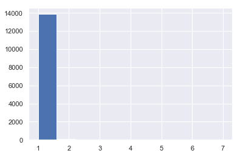

```python
check.TOT_PAG_VIEW_CT.hist()
```

```python
check.TOT_PAG_VIEW_CT.describe()
```

```
count    13937.000000
mean         1.005597
std          0.094921
min          1.000000
25%          1.000000
50%          1.000000
75%          1.000000
max          7.000000
Name: TOT_PAG_VIEW_CT, dtype: float64
```

거의 대부분 1이다. 그냥 한번 클릭하고 바로 뒤로 가기를 눌러서 SESSION HR이 차마 생기지 못한 것으로 보인다.

```python
data5[(data5.TOT_PAG_VIEW_CT.isnull()==True) & (data5.TOT_SESS_HR_V.isnull()==True)]
# TOT_PAG_VIEW_CT도 NaN이고, TOT_SESS_HR_V도 NaN일 경우 > 265개 행 아예 접속이 안된 경우 같다.
```

|  | CLNT_ID | SESS_ID | SESS_SEQ | SESS_DT | TOT_PAG_VIEW_CT | TOT_SESS_HR_V | DVC_CTG_NM | ZON_NM | CITY_NM | Month | Weekday |
| --- | --- | --- | --- | --- | --- | --- | --- | --- | --- | --- | --- |
| 11409 | 5075856 | 6836578 | 19 | 2018-06-08 | NaN | NaN | mobile | Seoul | Seoul | 6 | 4 |
| 26628 | 5368135 | 4391880 | 10 | 2018-07-18 | NaN | NaN | mobile | Chungcheongnam-do | Yeongi-gun | 7 | 2 |
| 43241 | 5687186 | 852560 | 40 | 2018-09-16 | NaN | NaN | mobile | Seoul | Seoul | 9 | 6 |
| 58494 | 6104032 | 1568619 | 78 | 2018-09-04 | NaN | NaN | mobile | Chungcheongnam-do | Cheonan-si | 9 | 1 |
| 64700 | 3735745 | 6884635 | 1 | 2018-06-07 | NaN | NaN | desktop | Gwangju | Gwangju | 6 | 3 |
| 72888 | 685173 | 6608500 | 16 | 2018-06-12 | NaN | NaN | mobile | Jeollanam-do | Yeosu-si | 6 | 1 |
| 78579 | 5360178 | 8534075 | 191 | 2018-05-11 | NaN | NaN | mobile | Gyeonggi-do | Goyang-si | 5 | 4 |
| 80904 | 5089253 | 2852934 | 24 | 2018-08-13 | NaN | NaN | mobile | Seoul | Seoul | 8 | 0 |
| 91070 | 887809 | 6282443 | 49 | 2018-06-17 | NaN | NaN | mobile | Daegu | Daegu | 6 | 6 |
| 107900 | 124859 | 1543135 | 9 | 2018-09-05 | NaN | NaN | mobile | Gyeonggi-do | Gimpo-si | 9 | 2 |
| 112413 | 3964085 | 6861843 | 42 | 2018-06-08 | NaN | NaN | mobile | Seoul | Seoul | 6 | 4 |
| 115617 | 1937442 | 7350667 | 4 | 2018-05-30 | NaN | NaN | mobile | Seoul | Seoul | 5 | 2 |
| 120189 | 4533466 | 8924428 | 5 | 2018-05-04 | NaN | NaN | mobile | Daegu | Daegu | 5 | 4 |
| 143093 | 9890 | 7052949 | 31 | 2018-06-04 | NaN | NaN | mobile | Seoul | Seoul | 6 | 0 |
| 149596 | 1673247 | 7122433 | 1 | 2018-06-03 | NaN | NaN | desktop | Daegu | Daegu | 6 | 6 |
| 156854 | 6090954 | 1025865 | 64 | 2018-09-13 | NaN | NaN | mobile | Seoul | Seoul | 9 | 3 |
| 158528 | 859658 | 8071269 | 23 | 2018-05-18 | NaN | NaN | mobile | Gyeongsangnam-do | Yangsan-si | 5 | 4 |
| 172397 | 5628 | 388082 | 30 | 2018-09-24 | NaN | NaN | mobile | Seoul | Seoul | 9 | 0 |
| 178923 | 1165396 | 8536467 | 54 | 2018-05-11 | NaN | NaN | mobile | Gyeonggi-do | Gimpo-si | 5 | 4 |
| 179358 | 1414648 | 4081483 | 321 | 2018-07-23 | NaN | NaN | mobile | Seoul | Seoul | 7 | 0 |
| 190527 | 4864135 | 3840635 | 35 | 2018-07-27 | NaN | NaN | mobile | Seoul | Seoul | 7 | 4 |
| 190529 | 4864135 | 3849609 | 33 | 2018-07-27 | NaN | NaN | mobile | Incheon | Incheon | 7 | 4 |
| 217104 | 406508 | 7114118 | 14 | 2018-06-03 | NaN | NaN | mobile | Busan | Busan | 6 | 6 |
| 232444 | 58842 | 2574753 | 21 | 2018-08-18 | NaN | NaN | mobile | Jeollabuk-do | Jeonju-si | 8 | 5 |
| 248675 | 5085285 | 7630020 | 9 | 2018-05-26 | NaN | NaN | mobile | Gyeonggi-do | Suwon-si | 5 | 5 |
| 254980 | 645598 | 8760156 | 3 | 2018-05-07 | NaN | NaN | mobile | Seoul | Seoul | 5 | 0 |
| 255342 | 5117190 | 4521786 | 27 | 2018-07-16 | NaN | NaN | mobile | Chungcheongnam-do | Asan-si | 7 | 0 |
| 256727 | 262574 | 9142780 | 140 | 2018-05-01 | NaN | NaN | mobile | Busan | Busan | 5 | 1 |
| 260380 | 1967210 | 5715295 | 10 | 2018-06-26 | NaN | NaN | mobile | Jeju-do | Jeju-si | 6 | 1 |
| 272470 | 1790583 | 5352996 | 12 | 2018-07-03 | NaN | NaN | mobile | Seoul | Seoul | 7 | 1 |
| ... | ... | ... | ... | ... | ... | ... | ... | ... | ... | ... | ... |
| 2443049 | 2774674 | 8278988 | 12 | 2018-05-15 | NaN | NaN | mobile | Gyeonggi-do | Bucheon-si | 5 | 1 |
| 2443050 | 2774674 | 8291841 | 8 | 2018-05-15 | NaN | NaN | mobile | Gyeonggi-do | Bucheon-si | 5 | 1 |
| 2443051 | 2774674 | 8288339 | 10 | 2018-05-15 | NaN | NaN | mobile | Gyeonggi-do | Bucheon-si | 5 | 1 |
| 2443052 | 2774674 | 8243940 | 14 | 2018-05-16 | NaN | NaN | mobile | Gyeonggi-do | Bucheon-si | 5 | 2 |
| 2443053 | 2774674 | 8146947 | 20 | 2018-05-17 | NaN | NaN | mobile | Daejeon | Daejeon | 5 | 3 |
| 2459246 | 1103207 | 9110870 | 20 | 2018-05-01 | NaN | NaN | mobile | Seoul | Seoul | 5 | 1 |
| 2481980 | 3162306 | 7225372 | 271 | 2018-06-02 | NaN | NaN | mobile | Chungcheongnam-do | Cheonan-si | 6 | 5 |
| 2487340 | 4030609 | 9564596 | 89 | 2018-04-24 | NaN | NaN | mobile | Seoul | Seoul | 4 | 1 |
| 2493941 | 4841239 | 6744849 | 1 | 2018-06-09 | NaN | NaN | desktop | Daejeon | Daejeon | 6 | 5 |
| 2535077 | 4482800 | 4965457 | 11 | 2018-07-09 | NaN | NaN | mobile | Seoul | Seoul | 7 | 0 |
| 2549218 | 6295526 | 10884786 | 232 | 2018-04-02 | NaN | NaN | mobile | Seoul | Seoul | 4 | 0 |
| 2555487 | 5612103 | 7419650 | 27 | 2018-05-29 | NaN | NaN | mobile | Seoul | Seoul | 5 | 1 |
| 2559039 | 4652838 | 9479610 | 17 | 2018-04-25 | NaN | NaN | mobile | Seoul | Seoul | 4 | 2 |
| 2572457 | 4499041 | 9564396 | 10 | 2018-04-24 | NaN | NaN | mobile | Gyeonggi-do | Yongin-si | 4 | 1 |
| 2585682 | 4795289 | 9606812 | 8 | 2018-04-23 | NaN | NaN | mobile | Busan | Busan | 4 | 0 |
| 2591845 | 5689529 | 8526388 | 10 | 2018-05-11 | NaN | NaN | mobile | Seoul | Seoul | 5 | 4 |
| 2597221 | 4076418 | 8476400 | 22 | 2018-05-12 | NaN | NaN | mobile | Daejeon | Daejeon | 5 | 5 |
| 2597223 | 4076418 | 8471136 | 24 | 2018-05-12 | NaN | NaN | mobile | Daejeon | Daejeon | 5 | 5 |
| 2613801 | 4179979 | 8405106 | 58 | 2018-05-13 | NaN | NaN | mobile | Chungcheongnam-do | Asan-si | 5 | 6 |
| 2616297 | 3866268 | 1181458 | 1 | 2018-09-11 | NaN | NaN | desktop | Seoul | Seoul | 9 | 1 |
| 2631341 | 4151697 | 10458795 | 8 | 2018-04-09 | NaN | NaN | mobile | Seoul | Seoul | 4 | 0 |
| 2631342 | 4151697 | 10886395 | 6 | 2018-04-02 | NaN | NaN | mobile | Gyeongsangbuk-do | Chilgok-gun | 4 | 0 |
| 2686641 | 2553487 | 1510814 | 1 | 2018-09-05 | NaN | NaN | desktop | Gyeonggi-do | Hwaseong-si | 9 | 2 |
| 2690902 | 5949974 | 9066789 | 25 | 2018-05-02 | NaN | NaN | mobile | Seoul | Seoul | 5 | 2 |
| 2694625 | 5222026 | 10695653 | 24 | 2018-04-05 | NaN | NaN | mobile | Daejeon | Daejeon | 4 | 3 |
| 2694819 | 5945452 | 4805081 | 8 | 2018-07-11 | NaN | NaN | mobile | Incheon | Incheon | 7 | 2 |
| 2695383 | 5317093 | 6650554 | 3 | 2018-06-11 | NaN | NaN | mobile | Gyeonggi-do | Goyang-si | 6 | 0 |
| 2699131 | 6042348 | 8834971 | 24 | 2018-05-06 | NaN | NaN | mobile | Seoul | Seoul | 5 | 6 |
| 2706558 | 5987591 | 4867294 | 111 | 2018-07-10 | NaN | NaN | mobile | Chungcheongnam-do | Yeongi-gun | 7 | 1 |
| 2710234 | 6139657 | 4168522 | 2 | 2018-07-22 | NaN | NaN | desktop | Busan | Busan | 7 | 6 |

265 rows × 11 columns

```python
data5 = data5[data5.TOT_PAG_VIEW_CT.isnull()==False]
```

```python
data5 = data5[data5.TOT_SESS_HR_V.isnull()==False]
```

### 형변환 마무리

```python
data5.TOT_PAG_VIEW_CT = data5.TOT_PAG_VIEW_CT.astype('int64')
data5.TOT_SESS_HR_V = data5.TOT_SESS_HR_V.apply(lambda x : x.replace(',','')) #쉼표 제거해준다.
data5.TOT_SESS_HR_V = data5.TOT_SESS_HR_V.astype('int64')
```

```python
data5
```

|  | CLNT_ID | SESS_ID | SESS_SEQ | SESS_DT | TOT_PAG_VIEW_CT | TOT_SESS_HR_V | DVC_CTG_NM | ZON_NM | CITY_NM | Month | Weekday |
| --- | --- | --- | --- | --- | --- | --- | --- | --- | --- | --- | --- |
| 0 | 5873599 | 8641867 | 9 | 2018-05-09 | 82 | 1890 | mobile | Daejeon | Daejeon | 5 | 2 |
| 1 | 5873599 | 6616320 | 21 | 2018-06-11 | 105 | 1604 | mobile | Busan | Busan | 6 | 0 |
| 2 | 5873599 | 5886172 | 40 | 2018-06-24 | 41 | 632 | mobile | Daejeon | Daejeon | 6 | 6 |
| 3 | 5873884 | 1050889 | 15 | 2018-09-13 | 160 | 1035 | mobile | Gyeonggi-do | Anyang | 9 | 3 |
| 4 | 5874461 | 10298270 | 5 | 2018-04-12 | 13 | 298 | mobile | Seoul | Seoul | 4 | 3 |
| 5 | 5874701 | 608577 | 65 | 2018-09-20 | 41 | 444 | mobile | Seoul | Seoul | 9 | 3 |
| 6 | 5874829 | 1666766 | 87 | 2018-09-03 | 36 | 340 | mobile | Seoul | Seoul | 9 | 0 |
| 7 | 5874829 | 1670494 | 86 | 2018-09-03 | 103 | 976 | mobile | Seoul | Seoul | 9 | 0 |
| 8 | 5874829 | 1694242 | 85 | 2018-09-02 | 154 | 3099 | mobile | Seoul | Seoul | 9 | 6 |
| 9 | 5874829 | 1559438 | 92 | 2018-09-04 | 24 | 317 | mobile | Seoul | Seoul | 9 | 1 |
| 10 | 5874900 | 10229983 | 7 | 2018-04-13 | 207 | 4143 | mobile | Seoul | Seoul | 4 | 4 |
| 11 | 5874907 | 10855 | 2 | 2018-09-30 | 4 | 263 | desktop | Gyeongsangbuk-do | Gumi-si | 9 | 6 |
| 12 | 5876333 | 348698 | 16 | 2018-09-25 | 159 | 786 | mobile | Seoul | Seoul | 9 | 1 |
| 13 | 5876333 | 456326 | 15 | 2018-09-23 | 160 | 1038 | mobile | Jeollabuk-do | Buan-gun | 9 | 6 |
| 14 | 5876333 | 584142 | 13 | 2018-09-20 | 33 | 312 | mobile | Seoul | Seoul | 9 | 3 |
| 15 | 5876382 | 2141725 | 17 | 2018-08-25 | 72 | 1104 | mobile | Seoul | Seoul | 8 | 5 |
| 16 | 5876382 | 4493736 | 5 | 2018-07-16 | 42 | 666 | mobile | Seoul | Seoul | 7 | 0 |
| 17 | 5876601 | 6940393 | 47 | 2018-06-06 | 38 | 288 | mobile | Seoul | Seoul | 6 | 2 |
| 18 | 5876630 | 1511171 | 156 | 2018-09-05 | 104 | 689 | mobile | Seoul | Seoul | 9 | 2 |
| 19 | 5876630 | 223471 | 165 | 2018-09-27 | 77 | 861 | mobile | Seoul | Seoul | 9 | 3 |
| 20 | 5876800 | 8513782 | 366 | 2018-05-11 | 53 | 1022 | mobile | Chungcheongbuk-do | Cheongju-si | 5 | 4 |
| 21 | 5876800 | 7153099 | 429 | 2018-06-03 | 174 | 2019 | mobile | Seoul | Seoul | 6 | 6 |
| 22 | 5876800 | 7904215 | 397 | 2018-05-21 | 188 | 860 | mobile | Chungcheongbuk-do | Cheongju-si | 5 | 0 |
| 23 | 5876800 | 3836347 | 491 | 2018-07-27 | 122 | 459 | mobile | Seoul | Seoul | 7 | 4 |
| 24 | 5876800 | 3627244 | 500 | 2018-07-31 | 95 | 673 | mobile | Seoul | Seoul | 7 | 1 |
| 25 | 5876800 | 6785647 | 437 | 2018-06-09 | 61 | 159 | mobile | Chungcheongbuk-do | Cheongju-si | 6 | 5 |
| 26 | 5876800 | 8603946 | 362 | 2018-05-10 | 128 | 949 | mobile | Chungcheongbuk-do | Cheongju-si | 5 | 3 |
| 27 | 5876800 | 3197247 | 517 | 2018-08-07 | 157 | 1216 | mobile | Seoul | Seoul | 8 | 1 |
| 28 | 5876800 | 2310513 | 533 | 2018-08-22 | 108 | 888 | mobile | Seoul | Seoul | 8 | 2 |
| 29 | 5876912 | 447981 | 36 | 2018-09-23 | 23 | 756 | mobile | Seoul | Seoul | 9 | 6 |
| ... | ... | ... | ... | ... | ... | ... | ... | ... | ... | ... | ... |
| 2712877 | 3555832 | 9296481 | 298 | 2018-04-28 | 338 | 3803 | mobile | Seoul | Seoul | 4 | 5 |
| 2712878 | 3552243 | 857890 | 70 | 2018-09-16 | 55 | 541 | mobile | Incheon | Incheon | 9 | 6 |
| 2712879 | 3553256 | 8128228 | 13 | 2018-05-18 | 39 | 341 | mobile | Seoul | Seoul | 5 | 4 |
| 2712880 | 3559213 | 8566684 | 167 | 2018-05-10 | 107 | 1014 | mobile | Incheon | Incheon | 5 | 3 |
| 2712881 | 3557770 | 5692621 | 377 | 2018-06-27 | 60 | 2236 | mobile | Gangwon-do | Wonju-si | 6 | 2 |
| 2712882 | 3557770 | 6833734 | 364 | 2018-06-08 | 104 | 1960 | mobile | Gangwon-do | Wonju-si | 6 | 4 |
| 2712883 | 3558515 | 8027926 | 199 | 2018-05-19 | 18 | 488 | mobile | Busan | Busan | 5 | 5 |
| 2712884 | 3561571 | 8410485 | 363 | 2018-05-13 | 123 | 3436 | mobile | Gyeongsangnam-do | Gimhae-si | 5 | 6 |
| 2712885 | 3569154 | 8031581 | 103 | 2018-05-19 | 152 | 1291 | mobile | Jeollabuk-do | Jeonju-si | 5 | 5 |
| 2712886 | 3566040 | 7612581 | 103 | 2018-05-26 | 56 | 705 | mobile | Gyeongsangnam-do | Gimhae-si | 5 | 5 |
| 2712887 | 3566629 | 6375372 | 95 | 2018-06-15 | 48 | 273 | mobile | Seoul | Seoul | 6 | 4 |
| 2712888 | 3568487 | 7191536 | 346 | 2018-06-02 | 41 | 441 | mobile | Busan | Busan | 6 | 5 |
| 2712889 | 3570334 | 5602994 | 2 | 2018-06-28 | 112 | 2611 | mobile | Gyeongsangbuk-do | Andong | 6 | 3 |
| 2712890 | 3642165 | 2189979 | 3 | 2018-08-24 | 29 | 1004 | desktop | Gyeonggi-do | Ansan-si | 8 | 4 |
| 2712891 | 3642354 | 4493999 | 83 | 2018-07-16 | 66 | 1719 | mobile | Gwangju | Gwangju | 7 | 0 |
| 2712892 | 3643587 | 10083218 | 12 | 2018-04-15 | 130 | 6203 | desktop | Ulsan | Ulsan | 4 | 6 |
| 2712893 | 3646640 | 6166681 | 16 | 2018-06-19 | 106 | 2177 | mobile | Busan | Busan | 6 | 1 |
| 2712894 | 3570720 | 4098757 | 500 | 2018-07-23 | 265 | 2246 | mobile | Daegu | Daegu | 7 | 0 |
| 2712895 | 3570720 | 3848780 | 515 | 2018-07-27 | 56 | 1039 | mobile | Busan | Busan | 7 | 4 |
| 2712896 | 3570720 | 5868666 | 454 | 2018-06-24 | 84 | 1589 | mobile | Daegu | Daegu | 6 | 6 |
| 2712897 | 3497799 | 8205641 | 1 | 2018-05-16 | 85 | 1828 | desktop | Daejeon | Daejeon | 5 | 2 |
| 2712898 | 3492307 | 2983998 | 25 | 2018-08-11 | 29 | 419 | mobile | Gwangju | Gwangju | 8 | 5 |
| 2712899 | 3499525 | 259993 | 2 | 2018-09-26 | 50 | 2477 | desktop | Chungcheongbuk-do | Jecheon-si | 9 | 2 |
| 2712900 | 3490918 | 1573185 | 16 | 2018-09-04 | 50 | 1546 | mobile | Busan | Busan | 9 | 1 |
| 2712901 | 3494680 | 9458833 | 488 | 2018-04-25 | 29 | 237 | mobile | Gyeonggi-do | Gimpo-si | 4 | 2 |
| 2712902 | 3500464 | 8713975 | 308 | 2018-05-08 | 71 | 423 | mobile | Seoul | Seoul | 5 | 1 |
| 2712903 | 3501155 | 4636571 | 86 | 2018-07-14 | 44 | 2090 | desktop | Seoul | Seoul | 7 | 5 |
| 2712904 | 3501397 | 582632 | 128 | 2018-09-20 | 164 | 2435 | mobile | Seoul | Seoul | 9 | 3 |
| 2712905 | 3573271 | 2328407 | 9 | 2018-08-22 | 5 | 986 | desktop | Busan | Busan | 8 | 2 |
| 2712906 | 3573758 | 8702345 | 17 | 2018-05-08 | 18 | 373 | desktop | Chungcheongbuk-do | Cheongju-si | 5 | 1 |

2698696 rows × 11 columns

```python
Session = data5
```

```python
import seaborn as sns
```

```python
sns.set(style='whitegrid')
```

```python
import matplotlib as mpl
import matplotlib.pyplot as plt
import matplotlib.font_manager as fm
```

```python
from matplotlib import rcParams
```

```python
print ('버전: ', mpl.__version__)
print ('설치 위치: ', mpl.__file__)
print ('설정 위치: ', mpl.get_configdir())
print ('캐시 위치: ', mpl.get_cachedir())
print ('설정파일 위치: ', mpl.matplotlib_fname())
# figure size in inches
rcParams['figure.figsize'] = 11.7,8.27
font_list = fm.findSystemFonts(fontpaths=None, fontext='ttf')

# ttf 폰트 전체갯수
print(len(font_list))
font_list[:10]
[(f.name, f.fname) for f in fm.fontManager.ttflist if 'Nanum' in f.name]

# size, family
print('# 설정 되어있는 폰트 사이즈')
print (plt.rcParams['font.size'] )
print('# 설정 되어있는 폰트 글꼴')
print (plt.rcParams['font.family'] )


plt.rcParams["font.family"] = 'NanumBarunGothic'
plt.rcParams["font.size"] = 10
```

```
버전:  2.2.2
설치 위치:  C:\Users\Jungwoo Lim\Anaconda3\lib\site-packages\matplotlib\__init__.py
설정 위치:  C:\Users\Jungwoo Lim\.matplotlib
캐시 위치:  C:\Users\Jungwoo Lim\.matplotlib
설정파일 위치:  C:\Users\Jungwoo Lim\Anaconda3\lib\site-packages\matplotlib\mpl-data\matplotlibrc
844
# 설정 되어있는 폰트 사이즈
12.0
# 설정 되어있는 폰트 글꼴
['sans-serif']
```

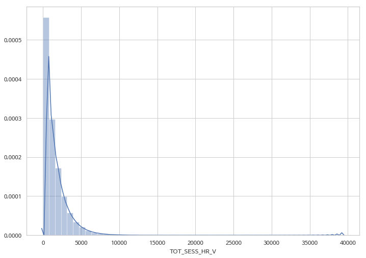

```python
sns.distplot(Session.TOT_SESS_HR_V)
```

```python
Session
```

|  | CLNT_ID | SESS_ID | SESS_SEQ | SESS_DT | TOT_PAG_VIEW_CT | TOT_SESS_HR_V | DVC_CTG_NM | ZON_NM | CITY_NM | Month | Weekday |
| --- | --- | --- | --- | --- | --- | --- | --- | --- | --- | --- | --- |
| 0 | 5873599 | 8641867 | 9 | 2018-05-09 | 82 | 1890 | mobile | Daejeon | Daejeon | 5 | 2 |
| 1 | 5873599 | 6616320 | 21 | 2018-06-11 | 105 | 1604 | mobile | Busan | Busan | 6 | 0 |
| 2 | 5873599 | 5886172 | 40 | 2018-06-24 | 41 | 632 | mobile | Daejeon | Daejeon | 6 | 6 |
| 3 | 5873884 | 1050889 | 15 | 2018-09-13 | 160 | 1035 | mobile | Gyeonggi-do | Anyang | 9 | 3 |
| 4 | 5874461 | 10298270 | 5 | 2018-04-12 | 13 | 298 | mobile | Seoul | Seoul | 4 | 3 |
| 5 | 5874701 | 608577 | 65 | 2018-09-20 | 41 | 444 | mobile | Seoul | Seoul | 9 | 3 |
| 6 | 5874829 | 1666766 | 87 | 2018-09-03 | 36 | 340 | mobile | Seoul | Seoul | 9 | 0 |
| 7 | 5874829 | 1670494 | 86 | 2018-09-03 | 103 | 976 | mobile | Seoul | Seoul | 9 | 0 |
| 8 | 5874829 | 1694242 | 85 | 2018-09-02 | 154 | 3099 | mobile | Seoul | Seoul | 9 | 6 |
| 9 | 5874829 | 1559438 | 92 | 2018-09-04 | 24 | 317 | mobile | Seoul | Seoul | 9 | 1 |
| 10 | 5874900 | 10229983 | 7 | 2018-04-13 | 207 | 4143 | mobile | Seoul | Seoul | 4 | 4 |
| 11 | 5874907 | 10855 | 2 | 2018-09-30 | 4 | 263 | desktop | Gyeongsangbuk-do | Gumi-si | 9 | 6 |
| 12 | 5876333 | 348698 | 16 | 2018-09-25 | 159 | 786 | mobile | Seoul | Seoul | 9 | 1 |
| 13 | 5876333 | 456326 | 15 | 2018-09-23 | 160 | 1038 | mobile | Jeollabuk-do | Buan-gun | 9 | 6 |
| 14 | 5876333 | 584142 | 13 | 2018-09-20 | 33 | 312 | mobile | Seoul | Seoul | 9 | 3 |
| 15 | 5876382 | 2141725 | 17 | 2018-08-25 | 72 | 1104 | mobile | Seoul | Seoul | 8 | 5 |
| 16 | 5876382 | 4493736 | 5 | 2018-07-16 | 42 | 666 | mobile | Seoul | Seoul | 7 | 0 |
| 17 | 5876601 | 6940393 | 47 | 2018-06-06 | 38 | 288 | mobile | Seoul | Seoul | 6 | 2 |
| 18 | 5876630 | 1511171 | 156 | 2018-09-05 | 104 | 689 | mobile | Seoul | Seoul | 9 | 2 |
| 19 | 5876630 | 223471 | 165 | 2018-09-27 | 77 | 861 | mobile | Seoul | Seoul | 9 | 3 |
| 20 | 5876800 | 8513782 | 366 | 2018-05-11 | 53 | 1022 | mobile | Chungcheongbuk-do | Cheongju-si | 5 | 4 |
| 21 | 5876800 | 7153099 | 429 | 2018-06-03 | 174 | 2019 | mobile | Seoul | Seoul | 6 | 6 |
| 22 | 5876800 | 7904215 | 397 | 2018-05-21 | 188 | 860 | mobile | Chungcheongbuk-do | Cheongju-si | 5 | 0 |
| 23 | 5876800 | 3836347 | 491 | 2018-07-27 | 122 | 459 | mobile | Seoul | Seoul | 7 | 4 |
| 24 | 5876800 | 3627244 | 500 | 2018-07-31 | 95 | 673 | mobile | Seoul | Seoul | 7 | 1 |
| 25 | 5876800 | 6785647 | 437 | 2018-06-09 | 61 | 159 | mobile | Chungcheongbuk-do | Cheongju-si | 6 | 5 |
| 26 | 5876800 | 8603946 | 362 | 2018-05-10 | 128 | 949 | mobile | Chungcheongbuk-do | Cheongju-si | 5 | 3 |
| 27 | 5876800 | 3197247 | 517 | 2018-08-07 | 157 | 1216 | mobile | Seoul | Seoul | 8 | 1 |
| 28 | 5876800 | 2310513 | 533 | 2018-08-22 | 108 | 888 | mobile | Seoul | Seoul | 8 | 2 |
| 29 | 5876912 | 447981 | 36 | 2018-09-23 | 23 | 756 | mobile | Seoul | Seoul | 9 | 6 |
| ... | ... | ... | ... | ... | ... | ... | ... | ... | ... | ... | ... |
| 2712877 | 3555832 | 9296481 | 298 | 2018-04-28 | 338 | 3803 | mobile | Seoul | Seoul | 4 | 5 |
| 2712878 | 3552243 | 857890 | 70 | 2018-09-16 | 55 | 541 | mobile | Incheon | Incheon | 9 | 6 |
| 2712879 | 3553256 | 8128228 | 13 | 2018-05-18 | 39 | 341 | mobile | Seoul | Seoul | 5 | 4 |
| 2712880 | 3559213 | 8566684 | 167 | 2018-05-10 | 107 | 1014 | mobile | Incheon | Incheon | 5 | 3 |
| 2712881 | 3557770 | 5692621 | 377 | 2018-06-27 | 60 | 2236 | mobile | Gangwon-do | Wonju-si | 6 | 2 |
| 2712882 | 3557770 | 6833734 | 364 | 2018-06-08 | 104 | 1960 | mobile | Gangwon-do | Wonju-si | 6 | 4 |
| 2712883 | 3558515 | 8027926 | 199 | 2018-05-19 | 18 | 488 | mobile | Busan | Busan | 5 | 5 |
| 2712884 | 3561571 | 8410485 | 363 | 2018-05-13 | 123 | 3436 | mobile | Gyeongsangnam-do | Gimhae-si | 5 | 6 |
| 2712885 | 3569154 | 8031581 | 103 | 2018-05-19 | 152 | 1291 | mobile | Jeollabuk-do | Jeonju-si | 5 | 5 |
| 2712886 | 3566040 | 7612581 | 103 | 2018-05-26 | 56 | 705 | mobile | Gyeongsangnam-do | Gimhae-si | 5 | 5 |
| 2712887 | 3566629 | 6375372 | 95 | 2018-06-15 | 48 | 273 | mobile | Seoul | Seoul | 6 | 4 |
| 2712888 | 3568487 | 7191536 | 346 | 2018-06-02 | 41 | 441 | mobile | Busan | Busan | 6 | 5 |
| 2712889 | 3570334 | 5602994 | 2 | 2018-06-28 | 112 | 2611 | mobile | Gyeongsangbuk-do | Andong | 6 | 3 |
| 2712890 | 3642165 | 2189979 | 3 | 2018-08-24 | 29 | 1004 | desktop | Gyeonggi-do | Ansan-si | 8 | 4 |
| 2712891 | 3642354 | 4493999 | 83 | 2018-07-16 | 66 | 1719 | mobile | Gwangju | Gwangju | 7 | 0 |
| 2712892 | 3643587 | 10083218 | 12 | 2018-04-15 | 130 | 6203 | desktop | Ulsan | Ulsan | 4 | 6 |
| 2712893 | 3646640 | 6166681 | 16 | 2018-06-19 | 106 | 2177 | mobile | Busan | Busan | 6 | 1 |
| 2712894 | 3570720 | 4098757 | 500 | 2018-07-23 | 265 | 2246 | mobile | Daegu | Daegu | 7 | 0 |
| 2712895 | 3570720 | 3848780 | 515 | 2018-07-27 | 56 | 1039 | mobile | Busan | Busan | 7 | 4 |
| 2712896 | 3570720 | 5868666 | 454 | 2018-06-24 | 84 | 1589 | mobile | Daegu | Daegu | 6 | 6 |
| 2712897 | 3497799 | 8205641 | 1 | 2018-05-16 | 85 | 1828 | desktop | Daejeon | Daejeon | 5 | 2 |
| 2712898 | 3492307 | 2983998 | 25 | 2018-08-11 | 29 | 419 | mobile | Gwangju | Gwangju | 8 | 5 |
| 2712899 | 3499525 | 259993 | 2 | 2018-09-26 | 50 | 2477 | desktop | Chungcheongbuk-do | Jecheon-si | 9 | 2 |
| 2712900 | 3490918 | 1573185 | 16 | 2018-09-04 | 50 | 1546 | mobile | Busan | Busan | 9 | 1 |
| 2712901 | 3494680 | 9458833 | 488 | 2018-04-25 | 29 | 237 | mobile | Gyeonggi-do | Gimpo-si | 4 | 2 |
| 2712902 | 3500464 | 8713975 | 308 | 2018-05-08 | 71 | 423 | mobile | Seoul | Seoul | 5 | 1 |
| 2712903 | 3501155 | 4636571 | 86 | 2018-07-14 | 44 | 2090 | desktop | Seoul | Seoul | 7 | 5 |
| 2712904 | 3501397 | 582632 | 128 | 2018-09-20 | 164 | 2435 | mobile | Seoul | Seoul | 9 | 3 |
| 2712905 | 3573271 | 2328407 | 9 | 2018-08-22 | 5 | 986 | desktop | Busan | Busan | 8 | 2 |
| 2712906 | 3573758 | 8702345 | 17 | 2018-05-08 | 18 | 373 | desktop | Chungcheongbuk-do | Cheongju-si | 5 | 1 |

2698696 rows × 11 columns

```python
check = pd.DataFrame(Session.DVC_CTG_NM.groupby([Session.DVC_CTG_NM,Session.SESS_DT]).count())
```

```python
check.columns = ['DVC_CTG_NM_CT']
```

```python
check = check.reset_index()
```

```python
check
```

|  | DVC_CTG_NM | SESS_DT | DVC_CTG_NM_CT |
| --- | --- | --- | --- |
| 0 | desktop | 2018-04-01 | 2215 |
| 1 | desktop | 2018-04-02 | 3457 |
| 2 | desktop | 2018-04-03 | 3394 |
| 3 | desktop | 2018-04-04 | 3360 |
| 4 | desktop | 2018-04-05 | 2878 |
| 5 | desktop | 2018-04-06 | 2419 |
| 6 | desktop | 2018-04-07 | 1560 |
| 7 | desktop | 2018-04-08 | 2142 |
| 8 | desktop | 2018-04-09 | 3486 |
| 9 | desktop | 2018-04-10 | 2877 |
| 10 | desktop | 2018-04-11 | 3257 |
| 11 | desktop | 2018-04-12 | 2655 |
| 12 | desktop | 2018-04-13 | 2409 |
| 13 | desktop | 2018-04-14 | 1573 |
| 14 | desktop | 2018-04-15 | 1969 |
| 15 | desktop | 2018-04-16 | 3363 |
| 16 | desktop | 2018-04-17 | 2798 |
| 17 | desktop | 2018-04-18 | 2590 |
| 18 | desktop | 2018-04-19 | 2553 |
| 19 | desktop | 2018-04-20 | 2368 |
| 20 | desktop | 2018-04-21 | 1567 |
| 21 | desktop | 2018-04-22 | 2136 |
| 22 | desktop | 2018-04-23 | 3621 |
| 23 | desktop | 2018-04-24 | 2932 |
| 24 | desktop | 2018-04-25 | 2655 |
| 25 | desktop | 2018-04-26 | 2696 |
| 26 | desktop | 2018-04-27 | 2416 |
| 27 | desktop | 2018-04-28 | 1509 |
| 28 | desktop | 2018-04-29 | 1859 |
| 29 | desktop | 2018-04-30 | 3134 |
| ... | ... | ... | ... |
| 519 | tablet | 2018-09-01 | 59 |
| 520 | tablet | 2018-09-02 | 63 |
| 521 | tablet | 2018-09-03 | 65 |
| 522 | tablet | 2018-09-04 | 48 |
| 523 | tablet | 2018-09-05 | 46 |
| 524 | tablet | 2018-09-06 | 34 |
| 525 | tablet | 2018-09-07 | 41 |
| 526 | tablet | 2018-09-08 | 45 |
| 527 | tablet | 2018-09-09 | 74 |
| 528 | tablet | 2018-09-10 | 41 |
| 529 | tablet | 2018-09-11 | 71 |
| 530 | tablet | 2018-09-12 | 55 |
| 531 | tablet | 2018-09-13 | 76 |
| 532 | tablet | 2018-09-14 | 69 |
| 533 | tablet | 2018-09-15 | 52 |
| 534 | tablet | 2018-09-16 | 74 |
| 535 | tablet | 2018-09-17 | 56 |
| 536 | tablet | 2018-09-18 | 59 |
| 537 | tablet | 2018-09-19 | 35 |
| 538 | tablet | 2018-09-20 | 35 |
| 539 | tablet | 2018-09-21 | 24 |
| 540 | tablet | 2018-09-22 | 31 |
| 541 | tablet | 2018-09-23 | 21 |
| 542 | tablet | 2018-09-24 | 30 |
| 543 | tablet | 2018-09-25 | 31 |
| 544 | tablet | 2018-09-26 | 72 |
| 545 | tablet | 2018-09-27 | 51 |
| 546 | tablet | 2018-09-28 | 49 |
| 547 | tablet | 2018-09-29 | 49 |
| 548 | tablet | 2018-09-30 | 64 |

549 rows × 3 columns

```python
check = pd.DataFrame(Session.DVC_CTG_NM.value_counts())
```

```python
check = check.reset_index()
```

```python
check
```

|  | index | DVC_CTG_NM |
| --- | --- | --- |
| 0 | mobile | 2277349 |
| 1 | desktop | 409349 |
| 2 | tablet | 11998 |

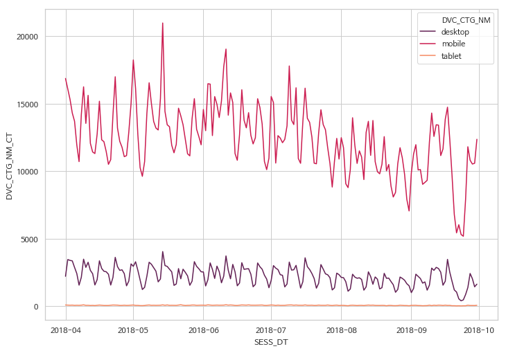

```python
sns.lineplot(x='SESS_DT',y='DVC_CTG_NM_CT',hue='DVC_CTG_NM',data=check,palette='rocket')
```

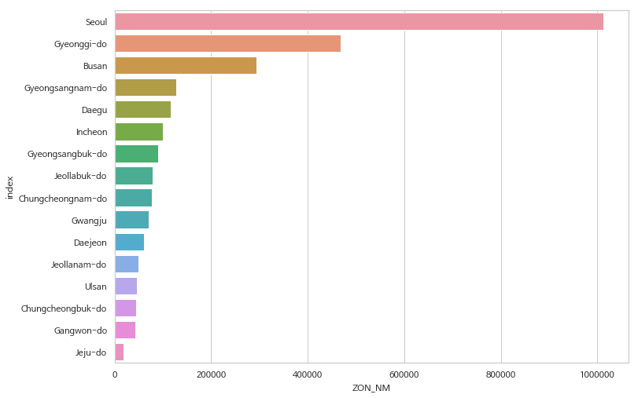

```python
sns.barplot(x='ZON_NM',y='index',data=check,capsize=8,)
```

```python
sns.despine(left=True, bottom=True)
```

```python
Session.DVC_CTG_NM
```

### 2.6 data6

```python
data6 = pd.read_csv('제5회 Big Data Competition-분석용데이터-06.Master.csv',delimiter="\r\t",engine='python',encoding='utf-8')
```

```python
data6
```

|  | PD_C,"PD_NM","CLAC1_NM","CLAC2_NM","CLAC3_NM" |
| --- | --- |
| 0 | "064382",언더아머 남성 UA HG 아머 모크 LS 1289559-001 - ... |
| 1 | "062282",여자 플라워덧신 2족선물세트 17403-2set,속옷/양말/홈웨어,... |
| 2 | "061729","88A2933253배트맨스웨트티 - 블랙 / 130",유아동의류,... |
| 3 | "061537","닥터마틴 아드리안 블랙, 체리레드 - 02_체리레드 / 250mm... |
| 4 | "058820",여성 그레이 스트라이프 퍼프 소매 블라우스 (128865YQ33) ... |
| 5 | "058280",선염스트라이프레이스패치원피스 JROP521D - 블루 / 85,여성... |
| 6 | "058183",[17S/S] 울 자카드 져지 자켓 9317111001056 - ... |
| 7 | "058098",V넥 고방 체크 롱 원피스 (K65-54615) - 스카이블루(SB... |
| 8 | "058057",배색포인트 랩스타일 원피스 (GIHOP921F) - 화이트 / F,... |
| 9 | "056306",선염 체크나염 여성잠옷(VPT3570WP) - 핑크 / 95,속옷/... |
| 10 | "055076",정장형스판바지C72P158 - 베이지(BE) / 55(90),여성의... |
| 11 | "318122","H1280YRJ,K,N토트백&크로스백 - 그레이",패션잡화,여성가... |
| 12 | "318011",가볍고 편안한 남성 워킹화 페이스투스 1117SW310 - 블랙 /... |
| 13 | "317956",체크패턴 프릴포인트 스커트GHB6SK740F - 078(민트) / ... |
| 14 | "127096",(KM)굿찌쿨통팬츠/빅사이즈/통바지/와이드팬츠 - 베이지 / 2번,... |
| 15 | "125372","8B-TS018 오곡벌룬소매티 - 빨강(Red) / 88",여성의... |
| 16 | "124084","여성백팩01H1280UBJ,UBN1FR - 그레이",패션잡화,여성... |
| 17 | "123395",네이비 하와이 5부 여성 파자마 EPF8678 - 90,속옷/양말/... |
| 18 | "123233",빅사이즈 헬로시스터 고호[마카롱머메이드 스커트] - ivory / ... |
| 19 | "122845",(2XL-5XL)바시트 원피스-6989 - 코코아 / 4XL,여성의... |
| 20 | "210546",컴포트 레터링자수 에코백 - 블랙,패션잡화,패션액세서리,기타패션잡화 |
| 21 | "209216",코튼 혼방 폴로 피케 반팔 티셔츠( TBMS1KTS23A0-B30)... |
| 22 | "216029",[보리보리/젤리스푼]l젤리스푼l베이직썸머7부가디건 - L블루/105... |
| 23 | "214635","280D 사틴햄 원단 기능성올인원WBT9330ABK - 블랙(DG... |
| 24 | "213856",한미 엔쵸비 오메가3 앤 비타민D 180정,건강식품,영양제,오메가3... |
| 25 | "213204","남여 솔리드캐주얼 5부바지 5217PH213,214,253,255... |
| 26 | "213185",스킬렛 16cm-매트블랙,식기/조리기구,조리기구,냄비 |
| 27 | "209786",쿠키커터클래식 6P,주방잡화,조리도구,제빵용품 |
| 28 | "206498",아일렛 A라인 롱 블라우스 - 베이지_BE / F(55~77),여성... |
| 29 | "202585",[스타일온미]쿨썸머 베브리지 나시티 - 아이보리 / S,여성의류,여... |
| ... | ... |
| 847622 | "062311",멀티 키즈 얌얌 클래식 후디_PKOEAHD01C - 옐로우-PKOE... |
| 847623 | "059440",[쁘리엘르]퍼피 극세사 강아지 카시트 M - 진그레이,원예/애완,애... |
| 847624 | "058550",[페리젠슨]스트레치 노턱 캐주얼팬츠 그레이.NPD17105 - 면바... |
| 847625 | "098413",피핀 셔링포인트 체크 롱원피스 #35455 - sora / FREE... |
| 847626 | "140822",[다이소]후레쉬직사각6L(김치통)-50812,세제/위생,세탁세제,분... |
| 847627 | "139180",라운드넥 자수 블라우스 (ENBA82633Z) - 네이비 / F,여... |
| 847628 | "134893",이중카라 세일러블라우스 NWBLIG6300 - 네이비 / 55,여성... |
| 847629 | "134134",민소매프릴원피스/M4631 - Cherryred / Free,여성의... |
| 847630 | "132356",참 인 캔디 시계 4종 택1 - 핑크 CHP-0217PK,패션잡화,... |
| 847631 | "131728","8B-PT213 포켓배색마7부팬츠 - 곤색(Navy) / 88",... |
| 847632 | "125539",[클리어런스] 컬렉션 웨어러블 아이팔레트 - 2호,화장품/뷰티케어,... |
| 847633 | "715809",스킨 파라솔 선스틱 15g,화장품/뷰티케어,선케어,선크림류 |
| 847634 | "715079",플레이도 칼라도우 4팩(B5517),완구,교육완구,미술/창작완구 |
| 847635 | "709441",[LECAF] 여성 워킹화 CAROLIN (LE_1117EW151_... |
| 847636 | "707873",진주 반팔 블라우스 BLI159 - 아이보리 / Free,여성의류,... |
| 847637 | "705374",인디고 빨간머리앤 클리어파일 [클리어화일/서류보관/문서/일러스트화일... |
| 847638 | "703105",여성 샌들 WAD1751GR21 - 네이비 / 225,패션잡화,여성... |
| 847639 | "702567",여성시계 AR11038 파슬코리아 직영,패션잡화,시계,여성시계 |
| 847640 | "701213",트렌디한 꽃무늬 오프숄더 롱 원피스 (CVOW72604Q) - 아이... |
| 847641 | "700904",가우퍼압력솥 6인용(통5중),식기/조리기구,조리기구,압력솥 |
| 847642 | "412759",뉴에이스 스트라이프 베이직 카라셔츠 AE8S401 - AE8S401... |
| 847643 | "410356",별 패턴 실크 스카프 ATSC8E100 - P2(핑크) / 5X84... |
| 847644 | "409376",팝바니 키즈 하트 스트라이프 클래식 티셔츠 화이트 - 팝바니키즈하트... |
| 847645 | "405748",폴란드95 구스다운 이불 싱글S.SS 1000 순면 속통 한파용 l... |
| 847646 | "400890",아디다스 D2M 로고 반팔티셔츠 (BK0937) - 105(XL),... |
| 847647 | "400721",[피핀] 클레르 박스 롱티셔츠 103764 - ivory / FRE... |
| 847648 | "400382",[바니플랫]여성플랫/BNF63011EN - 브라운 / 245 ◈83... |
| 847649 | "400197",섀르반 올인원 수영복 (K14D5DM231) - BL/110,시즌스... |
| 847650 | "399225",링클플리츠주름밴딩스커트(CFHM1SK8821) - 블랙 / FREE... |
| 847651 | "306289",클라이마쿨 쇼츠 [CX3564] - CX3564(그레이) / M,스... |

847652 rows × 1 columns

```python
data6.columns=['col_name']
```

```python
data6_1 = data6.col_name.str.split(",",expand=True,n=1)
```

```python
data6_1.columns = ['PD_C','REST']
```

```python
data6_final = pd.read_csv('no_name_Master.csv',encoding='euc-kr')
```

[output not shown]

```python
data6_final=data6_final.iloc[:,1:]
```

### 데이터 크기

```python
data6_final.info()
```

```
<class 'pandas.core.frame.DataFrame'>
RangeIndex: 847652 entries, 0 to 847651
Data columns (total 4 columns):
PD_C        847652 non-null int64
CLAC1_NM    847652 non-null object
CLAC2_NM    847652 non-null object
CLAC3_NM    847652 non-null object
dtypes: int64(1), object(3)
memory usage: 25.9+ MB
```

### 데이터 형변환 하자! (PD_C > object로)

```python
data6_final.PD_C = data6_final.PD_C.astype(str)
```

```python
data6_final.info()
```

```
<class 'pandas.core.frame.DataFrame'>
RangeIndex: 847652 entries, 0 to 847651
Data columns (total 4 columns):
PD_C        847652 non-null object
CLAC1_NM    847652 non-null object
CLAC2_NM    847652 non-null object
CLAC3_NM    847652 non-null object
dtypes: object(4)
memory usage: 25.9+ MB
```

### 데이터 기본 탐색

```python
data6_final.describe()
```

|  | PD_C | CLAC1_NM | CLAC2_NM | CLAC3_NM |
| --- | --- | --- | --- | --- |
| count | 847652 | 847652 | 847652 | 847652 |
| unique | 847652 | 37 | 128 | 898 |
| top | 155867 | 여성의류 | 여성의류상의 | 남성티셔츠 |
| freq | 1 | 181107 | 82731 | 41650 |

```python
data6_final.head(5)
```

|  | PD_C | CLAC1_NM | CLAC2_NM | CLAC3_NM |
| --- | --- | --- | --- | --- |
| 0 | 64382 | 스포츠패션 | 남성일반스포츠의류 | 남성스포츠티셔츠 |
| 1 | 62282 | 속옷/양말/홈웨어 | 여성양말류 | 여성일반양말 |
| 2 | 61729 | 유아동의류 | 유아의류상의 | 영유아티셔츠/탑 |
| 3 | 61537 | 패션잡화 | 남성화 | 남성부츠 |
| 4 | 58820 | 남성의류 | 남성의류상의 | 남성남방셔츠 |

```python
data6_final.tail(5)
```

|  | PD_C | CLAC1_NM | CLAC2_NM | CLAC3_NM |
| --- | --- | --- | --- | --- |
| 847647 | 400721 | 여성의류 | 여성의류상의 | 여성티셔츠/탑 |
| 847648 | 400382 | 패션잡화 | 여성화 | 여성플랫 |
| 847649 | 400197 | 시즌스포츠 | 수영/물놀이 | 아동수영복 |
| 847650 | 399225 | 여성의류 | 여성의류하의 | 여성스커트 |
| 847651 | 306289 | 스포츠패션 | 남성일반스포츠의류 | 남성일반스포츠바지 |

```python
data6_final.sample(5)
```

|  | PD_C | CLAC1_NM | CLAC2_NM | CLAC3_NM |
| --- | --- | --- | --- | --- |
| 576306 | 493405 | 여성의류 | 여성의류상의 | 여성남방셔츠 |
| 157470 | 637686 | 속옷/양말/홈웨어 | 여성속옷 | 브래지어 |
| 54181 | 337921 | 남성의류 | 남성의류상의 | 남성남방셔츠 |
| 690884 | 71455 | 남성의류 | 남성의류하의 | 남성정장바지 |
| 422239 | 202757 | 패션잡화 | 여성가방 | 여성토트백 |

### 중복값이 있는가?

```python
data6_final[data6_final.duplicated()==True] #없다.
```

|  | PD_C | CLAC1_NM | CLAC2_NM | CLAC3_NM |
| --- | --- | --- | --- | --- |

### NA값이 있는가?(Column 별로 보자!)

```python
data6_final[data6_final.PD_C.isnull()==True]
```

|  | PD_C | CLAC1_NM | CLAC2_NM | CLAC3_NM |
| --- | --- | --- | --- | --- |

```python
data6_final[data6_final.CLAC1_NM.isnull()==True]
```

|  | PD_C | CLAC1_NM | CLAC2_NM | CLAC3_NM |
| --- | --- | --- | --- | --- |

```python
data6_final[data6_final.CLAC2_NM.isnull()==True]
```

|  | PD_C | CLAC1_NM | CLAC2_NM | CLAC3_NM |
| --- | --- | --- | --- | --- |

```python
data6_final[data6_final.CLAC3_NM.isnull()==True]
```

|  | PD_C | CLAC1_NM | CLAC2_NM | CLAC3_NM |
| --- | --- | --- | --- | --- |

```python
Master = data6_final
```

```python
del(data6_final)
```

# EDA ver.2

```python
Product
```

|  | CLNT_ID | SESS_ID | HITS_SEQ | PD_C | PD_ADD_NM | PD_BRA_NM | PD_BUY_AM | PD_BUY_CT |
| --- | --- | --- | --- | --- | --- | --- | --- | --- |
| 0 | 4139680 | 7605037 | 12 | 642112 | 색상:워터멜론 | [바비브라운] | 39000 | 1 |
| 1 | 4140076 | 10189797 | 13 | 570603 | 색상:BLK0_(BLK0)BLACK\|사이즈:120 / 2개 | 데상트 | 39000 | 2 |
| 2 | 4142395 | 6158159 | 85 | 179538 | (not set) | [아베다] | 39000 | 1 |
| 3 | 4144914 | 7935714 | 12 | 554336 | 색상:블랙\|사이즈:160cm(12~13세) / 1개 | 아디다스 키즈 | 39000 | 1 |
| 4 | 4144917 | 6406509 | 78 | 190306 | 5개 | 데코르테 | 39000 | 5 |
| 5 | 4147643 | 4050743 | 66 | 149995 | 사이즈:옵션04.AN868_04 / 1개 | 앵글로매니아 | 39000 | 1 |
| 6 | 4147739 | 6881895 | 10 | 568751 | 신발색상:블랙(BK)/신발사이즈:280 | [디스커버리] | 39000 | 1 |
| 7 | 4148106 | 6537318 | 21 | 570603 | 색상:BLK0_(BLK0)BLACK\|사이즈:115 / 1개 | 데상트 | 39000 | 1 |
| 8 | 4148129 | 3942102 | 2 | 755148 | 모델명:올나이터 / 1개 | 어반디케이 | 39000 | 1 |
| 9 | 4148527 | 5718021 | 19 | 608620 | 사이즈:7 / 1개 | 나이키 | 39000 | 1 |
| 10 | 4150259 | 4098361 | 90 | 537513 | 색상:BLK/사이즈:105 | [아레나] | 39000 | 1 |
| 11 | 4153618 | 729571 | 42 | 77900 | 품번:3_JI9DSN12-MB/사이즈:29 | [잠뱅이] | 39000 | 1 |
| 12 | 4154576 | 4253415 | 19 | 591229 | size:S\|color:오프 화이트 / 1개 | 망고(MANGO) | 39000 | 1 |
| 13 | 4157355 | 6349580 | 34 | 554700 | 색상:WHT0_WHT0-(WHITE)\|사이즈:090 / 1개 | 르꼬끄 | 39000 | 1 |
| 14 | 4159738 | 3278944 | 42 | 184776 | 색상:BK\|사이즈:85 / 1개 | 레노마수영복 | 39000 | 1 |
| 15 | 4160219 | 9232020 | 32 | 368706 | 색상:화이트\|사이즈:100(L) / 1개 | 내셔널지오그래픽(남성) | 39000 | 1 |
| 16 | 4161209 | 3612192 | 247 | 125473 | 사이즈:110XXL / 1개 | 나이키(의류) | 39000 | 1 |
| 17 | 4167192 | 10832157 | 189 | 479110 | 색상:화이트(WH)\|사이즈:F / 1개 | 숲 | 39000 | 1 |
| 18 | 4169076 | 4316808 | 24 | 296741 | 색상:23호 트루베이지 / 2개 | 헤라 | 39000 | 2 |
| 19 | 4170352 | 4651820 | 387 | 166295 | 색상:(69)오렌지\|사이즈:55 / 1개 | 제이제이 지고트 | 39000 | 1 |
| 20 | 4171030 | 2287214 | 19 | 520151 | 색상:블루(BL)\|사이즈:15(165) / 1개 | 애스크 주니어 | 39000 | 1 |
| 21 | 4173605 | 9718934 | 23 | 636556 | 컬러:핑크 0806mpsnP / 1개 | 메트로시티(주얼리) | 39000 | 1 |
| 22 | 4174766 | 1738770 | 38 | 156410 | 상품명:루미에크림+루미에에센스 / 1개 | 르샤트라1802 | 39000 | 1 |
| 23 | 4177155 | 10750856 | 22 | 487558 | 바지사이즈:86(34) / 1개 | 제스 | 39000 | 1 |
| 24 | 4178471 | 675974 | 36 | 84340 | 색상:핑크 / 2개 | 박홍근 | 39000 | 2 |
| 25 | 4180381 | 10005643 | 169 | 571504 | 색상:민트\|사이즈:66 / 1개 | 라인 | 39000 | 1 |
| 26 | 4183066 | 1690031 | 51 | 65151 | 색상:화이트\|사이즈:105 / 1개 | 카운테스마라(셔츠) | 39000 | 1 |
| 27 | 4184092 | 10784068 | 141 | 457359 | 색상:블랙(BK)\|사이즈:115 / 1개 | 디스커버리 | 39000 | 1 |
| 28 | 4184818 | 4539154 | 2 | 167474 | 색상:네이비(N)/사이즈:145 | [엠엘비키즈] | 39000 | 1 |
| 29 | 4185920 | 6636436 | 46 | 581220 | 색상:블루\|사이즈:55 / 1개 | 리스트 | 39000 | 1 |
| ... | ... | ... | ... | ... | ... | ... | ... | ... |
| 5024876 | 4099176 | 8850749 | 102 | 672397 | 색상:네이비\|사이즈:55 / 1개 | 쉬즈미스 | 39000 | 1 |
| 5024877 | 4103067 | 10240533 | 47 | 467494 | 스타일:1.JK2106NA\|사이즈:100 / 1개 | 어반코드 | 39000 | 1 |
| 5024878 | 4104107 | 9203001 | 214 | 453584 | 색상:그린\|사이즈:55 / 1개 | 로엠 | 39000 | 1 |
| 5024879 | 4104395 | 5256411 | 120 | 704864 | 색상:BLK/사이즈:105 | [아레나(수영복)] | 39000 | 1 |
| 5024880 | 4107262 | 1270060 | 67 | 778307 | (not set) | [닥터자르트] | 39000 | 1 |
| 5024881 | 4108487 | 5079745 | 22 | 725745 | 타입:올 나이터 | [어반디케이] | 39000 | 1 |
| 5024882 | 4108900 | 2967180 | 27 | 642112 | 색상:카바나 / 1개 | 바비브라운 | 39000 | 1 |
| 5024883 | 4108900 | 2967180 | 56 | 642112 | 색상:카바나 / 1개 | 바비브라운 | 39000 | 1 |
| 5024884 | 4109607 | 61205 | 77 | 489144 | 1개 | 키엘 | 39000 | 1 |
| 5024885 | 4110447 | 6192376 | 114 | 391199 | 모델명:10. 0806mpnP / 1개 | 메트로시티(주얼리) | 39000 | 1 |
| 5024886 | 4111339 | 2566234 | 38 | 323529 | 1개 | 반다이 | 39000 | 1 |
| 5024887 | 4114333 | 9706699 | 71 | 489450 | 컬러:핑크\|사이즈:5/38(245mm) / 1개 | 락피쉬(구두) | 39000 | 1 |
| 5024888 | 4115601 | 5154938 | 30 | 642112 | 색상:워터멜론 / 1개 | 바비브라운 | 39000 | 1 |
| 5024889 | 4119818 | 4140131 | 87 | 139554 | 색상:INA\|사이즈:130 / 1개 | 휠라 키즈 | 39000 | 1 |
| 5024890 | 4121511 | 1184568 | 68 | 40071 | 색상:화이트\|사이즈:105 / 1개 | 코모도(남성) | 39000 | 1 |
| 5024891 | 4121682 | 8736148 | 37 | 399606 | 색상:아이보리1\|사이즈:FF / 1개 | 나무 | 39000 | 1 |
| 5024892 | 4121860 | 10876144 | 12 | 577503 | 색상:베이지\|사이즈:FREE / 1개 | 솔로이스트 | 39000 | 1 |
| 5024893 | 4123650 | 6943570 | 19 | 829673 | 색상:크림 / 1개 | 아가방 | 39000 | 1 |
| 5024894 | 4123943 | 5105759 | 11 | 786487 | 1개 | 닥터자르트 | 39000 | 1 |
| 5024895 | 4126622 | 10737750 | 15 | 716942 | 사이즈:55\|색상:화이트(WH) / 1개 | 쉬즈미스 | 39000 | 1 |
| 5024896 | 4127373 | 8591232 | 28 | 401577 | 색상:몰리 와우 / 1개 | 바비브라운 | 39000 | 1 |
| 5024897 | 4127769 | 8541560 | 95 | 571188 | 색상:BLK0_(BLK0)BLACK\|사이즈:110 / 1개 | 르꼬끄 | 39000 | 1 |
| 5024898 | 4128823 | 5004578 | 33 | 414556 | 선택1 상품(색상):(221)블랙\|선택2 사이즈:235 / 1개 | 스케쳐스 | 39000 | 1 |
| 5024899 | 4131574 | 8663581 | 5 | 489577 | 사이즈:275/색상:블랙 | [머렐] | 39000 | 1 |
| 5024900 | 4131835 | 1060339 | 145 | 53273 | 색상:1KK카키1\|사이즈:FF / 1개 | 나무 | 39000 | 1 |
| 5024901 | 4132078 | 10042817 | 76 | 527736 | 코드:s_kk_1205030\|사이즈:BLACK 90 / 1개 | 아디다스(의류) | 39000 | 1 |
| 5024902 | 4133768 | 7272433 | 31 | 284643 | 색상:(42)블루\|사이즈:55 / 1개 | 제이제이 지고트 | 39000 | 1 |
| 5024903 | 4133768 | 7946785 | 38 | 284643 | 색상:(60)아이보리\|사이즈:55 / 1개 | 제이제이 지고트 | 39000 | 1 |
| 5024904 | 4134952 | 5355187 | 113 | 840639 | 사이즈:Medium / 1개 | 배럴 | 39000 | 1 |
| 5024905 | 4136808 | 8930953 | 33 | 442584 | 색상:1.블랙/사이즈:M | [언더아머(스포츠)] | 39000 | 1 |

5024906 rows × 8 columns

```python
Product.info()
```

```
<class 'pandas.core.frame.DataFrame'>
RangeIndex: 5024906 entries, 0 to 5024905
Data columns (total 8 columns):
CLNT_ID      object
SESS_ID      object
HITS_SEQ     int64
PD_C         object
PD_ADD_NM    object
PD_BRA_NM    object
PD_BUY_AM    int64
PD_BUY_CT    int64
dtypes: int64(3), object(5)
memory usage: 306.7+ MB
```

```python
len(Product.CLNT_ID.unique()) #총 92만개 정도의 clientID가 생성되었다.
```

```
922737
```

```python
len(Product.SESS_ID.unique()) #총 242만개 정도의 sessionID가 생성되었다.
```

```
2425886
```

### Product랑 Session을 합쳐보자.

##### 그러면, 모바일로 와서 물을 사고, 구매 직후, 주스를 사게 된다면, 같은 ClientID와 같은 SessionID 로 다른 품목을 사게 된다. 그렇게 되면 Product와 Session 모두 row가 2개가 생기게 된다. 그런데 단순히 'ClientID'와 'SessID'를 기준으로 병합을 하게 된다면 한 쪽이 덮어씌워질 수 있는 위험을 인지하였다.

##### 그래서, 우리는 Product 내에, ClientID + SessionID 조합이 unique하다면, Session 내에 ClientID + SessionID + TOT_SESS_HR_V 조합도 unique할 것이라고 판단했다. 그래서 이를 증명한다면, 같은 ClientID와 같은 SessionID로 다른 품목을 산 케이스가 없다고 판단하는 것이다.

##### CLNT_ID 별로, SESS_ID가 중복되어있는지 확인했는데, 확인해보니 이가 없었다.

```python
Product.newindex = Product.CLNT_ID+Product.SESS_ID
```

```python
Session.TOT_SESS_HR_V = Session.TOT_SESS_HR_V.astype(str)
```

```python
Session.TOT_SESS_HR_V = Session.TOT_SESS_HR_V.fillna('a')
```

```python
Session.loc[Session.TOT_SESS_HR_V=='a']
```

|  | CLNT_ID | SESS_ID | SESS_SEQ | SESS_DT | TOT_PAG_VIEW_CT | TOT_SESS_HR_V | DVC_CTG_NM | ZON_NM | CITY_NM | Month | Weekday |
| --- | --- | --- | --- | --- | --- | --- | --- | --- | --- | --- | --- |

```python
Session.newindex = Session.CLNT_ID+Session.SESS_ID+Session.TOT_SESS_HR_V
```

```python
len(Product.newindex.unique())
```

```
2712907
```

```python
len(Session.newindex.unique())
```

```
2698696
```

### 그럼 일단 합쳐보자.

```python
Prod_Sess = pd.merge(Product, Session, on=['SESS_ID'])
```

```python
Prod_Sess.info()
```

```
<class 'pandas.core.frame.DataFrame'>
Int64Index: 6157817 entries, 0 to 6157816
Data columns (total 18 columns):
CLNT_ID_x          object
SESS_ID            object
HITS_SEQ           int64
PD_C               object
PD_ADD_NM          object
PD_BRA_NM          object
PD_BUY_AM          int64
PD_BUY_CT          int64
CLNT_ID_y          object
SESS_SEQ           int64
SESS_DT            datetime64[ns]
TOT_PAG_VIEW_CT    int64
TOT_SESS_HR_V      object
DVC_CTG_NM         object
ZON_NM             object
CITY_NM            object
Month              int64
Weekday            int64
dtypes: datetime64[ns](1), int64(7), object(10)
memory usage: 892.6+ MB
```

#### Q) CLNT_ID가 다른데 SESS_ID가 같을 수 있을까?

```python
CID_SID_diff = Prod_Sess.loc[Prod_Sess.CLNT_ID_x!=Prod_Sess.CLNT_ID_y]
```

```python
CID_SID_diff
```

|  | CLNT_ID_x | SESS_ID | HITS_SEQ | PD_C | PD_ADD_NM | PD_BRA_NM | PD_BUY_AM | PD_BUY_CT | CLNT_ID_y | SESS_SEQ | SESS_DT | TOT_PAG_VIEW_CT | TOT_SESS_HR_V | DVC_CTG_NM | ZON_NM | CITY_NM | Month | Weekday |
| --- | --- | --- | --- | --- | --- | --- | --- | --- | --- | --- | --- | --- | --- | --- | --- | --- | --- | --- |
| 20 | 4148129 | 3942102 | 2 | 755148 | 모델명:올나이터 / 1개 | 어반디케이 | 39000 | 1 | 2215130 | 1 | 2018-07-25 | 91 | 3030 | desktop | Gyeongsangnam-do | Geochang-gun | 7 | 2 |
| 21 | 4148129 | 3942102 | 2 | 755148 | 모델명:올나이터 / 1개 | 어반디케이 | 39000 | 1 | 4370295 | 4 | 2018-07-25 | 158 | 2190 | mobile | Gyeonggi-do | Namyangju-si | 7 | 2 |
| 22 | 4370295 | 3942102 | 160 | 641750 | 색상:NV\|사이즈:90/BU/WH/ / 1개 | 레노마수영복 | 40000 | 1 | 2215130 | 1 | 2018-07-25 | 91 | 3030 | desktop | Gyeongsangnam-do | Geochang-gun | 7 | 2 |
| 25 | 2215130 | 3942102 | 104 | 136921 | 색상:BKD/사이즈:100 | [탑텐] | 9000 | 1 | 4370295 | 4 | 2018-07-25 | 158 | 2190 | mobile | Gyeonggi-do | Namyangju-si | 7 | 2 |
| 27 | 2215130 | 3942102 | 104 | 324561 | 색상:선택02_WTV/사이즈:100 | [탑텐] | 9000 | 1 | 4370295 | 4 | 2018-07-25 | 158 | 2190 | mobile | Gyeonggi-do | Namyangju-si | 7 | 2 |
| 28 | 4148129 | 3942102 | 2 | 736986 | 1개 | 베네피트 | 17000 | 1 | 2215130 | 1 | 2018-07-25 | 91 | 3030 | desktop | Gyeongsangnam-do | Geochang-gun | 7 | 2 |
| 29 | 4148129 | 3942102 | 2 | 736986 | 1개 | 베네피트 | 17000 | 1 | 4370295 | 4 | 2018-07-25 | 158 | 2190 | mobile | Gyeonggi-do | Namyangju-si | 7 | 2 |
| 31 | 4150259 | 4098361 | 90 | 537513 | 색상:BLK/사이즈:105 | [아레나] | 39000 | 1 | 2315907 | 111 | 2018-07-23 | 213 | 2746 | mobile | Gyeonggi-do | Anyang | 7 | 0 |
| 34 | 2315907 | 4098361 | 99 | 100664 | 스타일번호:858430-011\|사이즈:085(M) / 1개 | 나이키(슈즈) | 48500 | 1 | 4150259 | 33 | 2018-07-23 | 80 | 4120 | desktop | Gyeongsangbuk-do | Gyeongju-si | 7 | 0 |
| 36 | 2315907 | 4098361 | 99 | 163212 | 사이즈:026 / 1개 | 록시 | 31000 | 1 | 4150259 | 33 | 2018-07-23 | 80 | 4120 | desktop | Gyeongsangbuk-do | Gyeongju-si | 7 | 0 |
| 37 | 4150259 | 4098361 | 90 | 223954 | COLOR:핑크-PINK/SIZE:FREE | [세인트마리] | 32400 | 1 | 2315907 | 111 | 2018-07-23 | 213 | 2746 | mobile | Gyeonggi-do | Anyang | 7 | 0 |
| 39 | 4150259 | 4098361 | 90 | 107606 | 색상:아이보리/사이즈:FREE | [포커스] | 34800 | 1 | 2315907 | 111 | 2018-07-23 | 213 | 2746 | mobile | Gyeonggi-do | Anyang | 7 | 0 |
| 57 | 4169076 | 4316808 | 24 | 296741 | 색상:23호 트루베이지 / 2개 | 헤라 | 39000 | 2 | 2149095 | 34 | 2018-07-19 | 91 | 879 | mobile | Seoul | Seoul | 7 | 3 |
| 59 | 4169076 | 4316808 | 24 | 540406 | 색상:카키\|Size:M / 1개 | 에잇세컨즈 | 12900 | 1 | 2149095 | 34 | 2018-07-19 | 91 | 879 | mobile | Seoul | Seoul | 7 | 3 |
| 60 | 2149095 | 4316808 | 62 | 451203 | 색상선택:블랙\|사이즈선택:XL / 1개 | 배럴 | 28000 | 1 | 4169076 | 505 | 2018-07-19 | 37 | 245 | mobile | Busan | Busan | 7 | 3 |
| 62 | 2149095 | 4316808 | 26 | 451203 | 색상선택:블랙\|사이즈선택:XL / 1개 | 배럴 | 28000 | 1 | 4169076 | 505 | 2018-07-19 | 37 | 245 | mobile | Busan | Busan | 7 | 3 |
| 64 | 2149095 | 4316808 | 62 | 450853 | 색상선택:단일색상\|사이즈선택:Large / 1개 | 배럴 | 29000 | 1 | 4169076 | 505 | 2018-07-19 | 37 | 245 | mobile | Busan | Busan | 7 | 3 |
| 69 | 4171030 | 2287214 | 19 | 520151 | 색상:블루(BL)\|사이즈:15(165) / 1개 | 애스크 주니어 | 39000 | 1 | 2564437 | 1 | 2018-08-23 | 14 | 2454 | desktop | Gyeonggi-do | Uiwang-si | 8 | 3 |
| 70 | 4171030 | 2287214 | 19 | 520151 | 색상:블루(BL)\|사이즈:15(165) / 1개 | 애스크 주니어 | 39000 | 1 | 5694059 | 1 | 2018-08-23 | 6 | 192 | desktop | Jeollabuk-do | Iksan | 8 | 3 |
| 71 | 2564437 | 2287214 | 15 | 97244 | 색상:레몬(140)/사이즈:130 | [네파키즈] | 47500 | 1 | 4171030 | 107 | 2018-08-23 | 18 | 69 | mobile | Busan | Busan | 8 | 3 |
| 73 | 2564437 | 2287214 | 15 | 97244 | 색상:레몬(140)/사이즈:130 | [네파키즈] | 47500 | 1 | 5694059 | 1 | 2018-08-23 | 6 | 192 | desktop | Jeollabuk-do | Iksan | 8 | 3 |
| 74 | 2564437 | 2287214 | 15 | 65769 | 색상:오렌지/사이즈:130 | [네파키즈] | 5900 | 1 | 4171030 | 107 | 2018-08-23 | 18 | 69 | mobile | Busan | Busan | 8 | 3 |
| 76 | 2564437 | 2287214 | 15 | 65769 | 색상:오렌지/사이즈:130 | [네파키즈] | 5900 | 1 | 5694059 | 1 | 2018-08-23 | 6 | 192 | desktop | Jeollabuk-do | Iksan | 8 | 3 |
| 77 | 2564437 | 2287214 | 15 | 428680 | 색상:BK/사이즈:130 | [블랙야크(키즈)] | 59000 | 1 | 4171030 | 107 | 2018-08-23 | 18 | 69 | mobile | Busan | Busan | 8 | 3 |
| 79 | 2564437 | 2287214 | 15 | 428680 | 색상:BK/사이즈:130 | [블랙야크(키즈)] | 59000 | 1 | 5694059 | 1 | 2018-08-23 | 6 | 192 | desktop | Jeollabuk-do | Iksan | 8 | 3 |
| 80 | 5694059 | 2287214 | 7 | 109633 | 색상:검정(Black)/사이즈:FREE(66-77) | [데드라] | 68800 | 1 | 4171030 | 107 | 2018-08-23 | 18 | 69 | mobile | Busan | Busan | 8 | 3 |
| 81 | 5694059 | 2287214 | 7 | 109633 | 색상:검정(Black)/사이즈:FREE(66-77) | [데드라] | 68800 | 1 | 2564437 | 1 | 2018-08-23 | 14 | 2454 | desktop | Gyeonggi-do | Uiwang-si | 8 | 3 |
| 85 | 4174766 | 1738770 | 38 | 156410 | 상품명:루미에크림+루미에에센스 / 1개 | 르샤트라1802 | 39000 | 1 | 2786696 | 18 | 2018-09-01 | 46 | 205 | mobile | Seoul | Seoul | 9 | 5 |
| 86 | 2786696 | 1738770 | 44 | 756753 | SIZE:38 / 1개 | 페이유에 | 59000 | 1 | 4174766 | 81 | 2018-09-01 | 32 | 442 | mobile | Gyeonggi-do | Namyangju-si | 9 | 5 |
| 89 | 4174766 | 1738770 | 38 | 297034 | 상품명:[르샤트라]루미에 퓨리파잉 토너 250ml / 1개 | 르샤트라1802 | 9900 | 1 | 2786696 | 18 | 2018-09-01 | 46 | 205 | mobile | Seoul | Seoul | 9 | 5 |
| ... | ... | ... | ... | ... | ... | ... | ... | ... | ... | ... | ... | ... | ... | ... | ... | ... | ... | ... |
| 6137954 | 1165599 | 10143182 | 152 | 656192 | 색상:780_BRICK\|사이즈:55 / 1개 | 더아이잗(여성) | 39000 | 1 | 4134997 | 9 | 2018-04-14 | 13 | 122 | mobile | Gyeonggi-do | Bucheon-si | 4 | 5 |
| 6137955 | 4134997 | 10143182 | 14 | 725732 | 1개 | 바비온 | 39800 | 1 | 1165599 | 368 | 2018-04-14 | 345 | 3364 | mobile | Gyeonggi-do | Seongnam-si | 4 | 5 |
| 6138173 | 6527880 | 77379 | 58 | 831618 | 1개 | 올즙 | 38900 | 1 | 2520739 | 14 | 2018-09-29 | 71 | 870 | mobile | Gyeonggi-do | Namyangju-si | 9 | 5 |
| 6138176 | 2520739 | 77379 | 84 | 522811 | 모델명:06627-ROSA\|사이즈:180mm(EU29) / 1개 | 빅토리아 | 39800 | 1 | 6527880 | 105 | 2018-09-29 | 58 | 477 | mobile | Gyeonggi-do | Osan-si | 9 | 5 |
| 6139696 | 802046 | 5244834 | 50 | 670667 | 색상:블루(BL)\|사이즈:77 / 1개 | 쉬즈미스 | 39000 | 1 | 3390328 | 6 | 2018-07-04 | 23 | 1703 | desktop | Seoul | Seoul | 7 | 2 |
| 6139697 | 3390328 | 5244834 | 24 | 608133 | 품번:선택15_ATBPM09JAD/사이즈:095 | [아레나(수영복)] | 39000 | 1 | 802046 | 51 | 2018-07-04 | 54 | 527 | mobile | Gangwon-do | Gangneung-si | 7 | 2 |
| 6139790 | 4732140 | 4068804 | 27 | 755148 | 모델명:올나이터 / 1개 | 어반디케이 | 39000 | 1 | 4119095 | 208 | 2018-07-23 | 85 | 667 | mobile | Seoul | Seoul | 7 | 0 |
| 6139791 | 4119095 | 4068804 | 81 | 225741 | 색상:(60)아이보리\|사이즈:66 / 1개 | 제이제이 지고트 | 39000 | 1 | 4732140 | 1 | 2018-07-23 | 36 | 469 | mobile | Gyeonggi-do | Gwangmyeong-si | 7 | 0 |
| 6141955 | 2062482 | 1417209 | 39 | 418116 | 1개 | 록시땅 | 39000 | 1 | 259033 | 43 | 2018-09-07 | 18 | 167 | mobile | Seoul | Seoul | 9 | 4 |
| 6141956 | 259033 | 1417209 | 18 | 185071 | 사이즈:W5 / 1개 | 크록스 | 39900 | 1 | 2062482 | 52 | 2018-09-07 | 54 | 838 | mobile | Seoul | Seoul | 9 | 4 |
| 6142131 | 1742847 | 9712263 | 18 | 356794 | 색상:블루(22)\|사이즈:01(55) / 1개 | 올리브데올리브 | 39000 | 1 | 2516808 | 164 | 2018-04-21 | 63 | 446 | mobile | Seoul | Seoul | 4 | 5 |
| 6142132 | 2516808 | 9712263 | 53 | 402721 | 색상:LT-GREY(34)\|사이즈:066 / 1개 | 숲 | 39000 | 1 | 1742847 | 260 | 2018-04-21 | 54 | 964 | mobile | Gyeongsangbuk-do | Pohang-si | 4 | 5 |
| 6143090 | 1978727 | 4399695 | 9 | 132559 | 색상:062(블루)/사이즈:S(55) | [지지피엑스] | 39000 | 1 | 4996820 | 62 | 2018-07-18 | 43 | 400 | mobile | Seoul | Seoul | 7 | 2 |
| 6143091 | 4996820 | 4399695 | 16 | 111886 | 색상:블랙(BK)\|사이즈:66 / 1개 | 리스트 | 39000 | 1 | 1978727 | 203 | 2018-07-18 | 94 | 18541 | desktop | Seoul | Seoul | 7 | 2 |
| 6143684 | 6541167 | 6715960 | 5 | 796128 | 컬러:핑크 / 1개 | 메트로시티(주얼리) | 39000 | 1 | 2204420 | 166 | 2018-06-10 | 23 | 166 | mobile | Incheon | Incheon | 6 | 6 |
| 6143687 | 2204420 | 6715960 | 14 | 486278 | 사이즈:100 / 1개 | 헤지스남성 | 39200 | 1 | 6541167 | 3 | 2018-06-10 | 7 | 169 | mobile | Seoul | Seoul | 6 | 6 |
| 6144682 | 1113498 | 826000 | 38 | 403982 | 색상:블루\|사이즈:160 / 1개 | 아디다스(키즈) | 39000 | 1 | 4636541 | 13 | 2018-09-16 | 24 | 499 | mobile | Incheon | Incheon | 9 | 6 |
| 6144683 | 4636541 | 826000 | 20 | 661950 | 선택:01_WF49946\|사이즈:230 / 1개 | 케즈 | 39800 | 1 | 1113498 | 127 | 2018-09-16 | 62 | 668 | mobile | Seoul | Seoul | 9 | 6 |
| 6144905 | 2228652 | 6577182 | 105 | 185465 | 색상:블루\|사이즈:S / 1개 | 나인(NAIN) | 39000 | 1 | 6310065 | 5 | 2018-06-12 | 46 | 874 | mobile | Seoul | Seoul | 6 | 1 |
| 6144908 | 6310065 | 6577182 | 12 | 304773 | 사이즈:C12(190mm) / 1개 | 크록스 | 39900 | 1 | 2228652 | 128 | 2018-06-12 | 106 | 273 | mobile | Seoul | Seoul | 6 | 1 |
| 6145235 | 2431752 | 9503194 | 25 | 500526 | 1개 | 텐바이텐 | 39000 | 1 | 296141 | 74 | 2018-04-25 | 50 | 657 | mobile | Seoul | Seoul | 4 | 2 |
| 6145238 | 296141 | 9503194 | 51 | 816627 | 1개 | 고려은단 | 39900 | 1 | 2431752 | 815 | 2018-04-25 | 24 | 494 | mobile | Seoul | Seoul | 4 | 2 |
| 6146337 | 5342634 | 294757 | 52 | 531230 | 색상:케일그린\|사이즈:77 / 1개 | 컬쳐콜 | 39000 | 1 | 4950843 | 165 | 2018-09-26 | 74 | 746 | mobile | Busan | Busan | 9 | 2 |
| 6146338 | 4950843 | 294757 | 51 | 13145 | 구성:블랙\|사이즈:88 / 1개 | 스튜디오 럭스 | 39000 | 1 | 5342634 | 198 | 2018-09-26 | 54 | 729 | mobile | Seoul | Seoul | 9 | 2 |
| 6147192 | 1600517 | 7383876 | 22 | 568379 | 색상:SKIN+BLACK\|사이즈:FREE / 1개 | 세컨스킨 | 39800 | 1 | 4794043 | 223 | 2018-05-30 | 73 | 1403 | mobile | Seoul | Seoul | 5 | 2 |
| 6147193 | 4794043 | 7383876 | 73 | 710563 | 품번:3.GEXH201_39(블랙)\|사이즈:250 / 1개 | 블랙마틴싯봉 | 39000 | 1 | 1600517 | 509 | 2018-05-30 | 36 | 193 | mobile | Gyeonggi-do | Anyang | 5 | 2 |
| 6148539 | 5139591 | 8729340 | 11 | 314549 | 색상:프렌치(Q)_블루 / 1개 | 쉬즈홈 | 39870 | 1 | 5802173 | 675 | 2018-05-08 | 325 | 4891 | mobile | Gangwon-do | Chuncheon-si | 5 | 1 |
| 6148540 | 5802173 | 8729340 | 317 | 398445 | 색상:화이트\|사이즈:M / 1개 | 디니지아 | 39800 | 1 | 5139591 | 895 | 2018-05-08 | 21 | 408 | mobile | Busan | Busan | 5 | 1 |
| 6156559 | 2072524 | 5830419 | 23 | 841549 | 종류:3단계 남48x3팩 / 1개 | 하기스 | 39900 | 1 | 5249705 | 422 | 2018-06-25 | 64 | 508 | mobile | Seoul | Seoul | 6 | 0 |
| 6156562 | 5249705 | 5830419 | 61 | 538924 | 색상:남성 네이비(176)\|사이즈:82 / 1개 | 머렐(레저) | 39000 | 1 | 2072524 | 278 | 2018-06-25 | 22 | 155 | mobile | Incheon | Incheon | 6 | 0 |

1153250 rows × 18 columns

#### A) 역시 랜덤이기 때문에 중복값이 있을 수 있다. 그러므로 merge할 때, key를 두 개로 설정해야 한다.

```python
Prod_Sess = pd.merge(Product, Session, on=['CLNT_ID','SESS_ID'],how='left')
```

```python
Prod_Sess.info()
```

```
<class 'pandas.core.frame.DataFrame'>
Int64Index: 5024906 entries, 0 to 5024905
Data columns (total 17 columns):
CLNT_ID            object
SESS_ID            object
HITS_SEQ           int64
PD_C               object
PD_ADD_NM          object
PD_BRA_NM          object
PD_BUY_AM          int64
PD_BUY_CT          int64
SESS_SEQ           float64
SESS_DT            datetime64[ns]
TOT_PAG_VIEW_CT    float64
TOT_SESS_HR_V      object
DVC_CTG_NM         object
ZON_NM             object
CITY_NM            object
Month              float64
Weekday            float64
dtypes: datetime64[ns](1), float64(4), int64(3), object(9)
memory usage: 690.1+ MB
```

그리고 이 둘을 합쳐도 크기가 늘어나면 안되는데, 확인해보자.

```python
Prod_Sess.info()
```

```
<class 'pandas.core.frame.DataFrame'>
Int64Index: 5024906 entries, 0 to 5024905
Data columns (total 17 columns):
CLNT_ID            object
SESS_ID            object
HITS_SEQ           int64
PD_C               object
PD_ADD_NM          object
PD_BRA_NM          object
PD_BUY_AM          int64
PD_BUY_CT          int64
SESS_SEQ           float64
SESS_DT            datetime64[ns]
TOT_PAG_VIEW_CT    float64
TOT_SESS_HR_V      object
DVC_CTG_NM         object
ZON_NM             object
CITY_NM            object
Month              float64
Weekday            float64
dtypes: datetime64[ns](1), float64(4), int64(3), object(9)
memory usage: 690.1+ MB
```

혹시 결측값이 있는지 확인해보자.

```python
Prod_Sess.loc[Prod_Sess.SESS_DT.isnull()==True]
```

|  | CLNT_ID | SESS_ID | HITS_SEQ | PD_C | PD_ADD_NM | PD_BRA_NM | PD_BUY_AM | PD_BUY_CT | SESS_SEQ | SESS_DT | TOT_PAG_VIEW_CT | TOT_SESS_HR_V | DVC_CTG_NM | ZON_NM | CITY_NM | Month | Weekday |
| --- | --- | --- | --- | --- | --- | --- | --- | --- | --- | --- | --- | --- | --- | --- | --- | --- | --- |
| 8 | 4148129 | 3942102 | 2 | 755148 | 모델명:올나이터 / 1개 | 어반디케이 | 39000 | 1 | NaN | NaT | NaN | NaN | NaN | NaN | NaN | NaN | NaN |
| 249 | 5120823 | 536203 | 2 | 19166 | 색상:1BK블랙1/사이즈:FF | [나무] | 39000 | 1 | NaN | NaT | NaN | NaN | NaN | NaN | NaN | NaN | NaN |
| 1354 | 4729384 | 617816 | 2 | 40647 | 색상:민트/사이즈:55 | [다니엘에스떼] | 39000 | 1 | NaN | NaT | NaN | NaN | NaN | NaN | NaN | NaN | NaN |
| 1369 | 4758889 | 10604012 | 1 | 776358 | 사이즈:28 / 1개 | 게스(진) | 39000 | 1 | NaN | NaT | NaN | NaN | NaN | NaN | NaN | NaN | NaN |
| 1390 | 2941375 | 9520228 | 2 | 816627 | 1개 | 고려은단 | 39900 | 1 | NaN | NaT | NaN | NaN | NaN | NaN | NaN | NaN | NaN |
| 1411 | 3100175 | 10917202 | 2 | 464238 | 색상:WTP(화이트패턴)\|사이즈:95 / 1개 | 탑텐 | 39900 | 1 | NaN | NaT | NaN | NaN | NaN | NaN | NaN | NaN | NaN |
| 1473 | 3447350 | 3617853 | 2 | 344414 | 색상:블랙\|사이즈:77 / 1개 | 클라비스 | 39900 | 1 | NaN | NaT | NaN | NaN | NaN | NaN | NaN | NaN | NaN |
| 1557 | 1391274 | 5391480 | 2 | 302705 | 품번:02.CROCS_204804_101_\|사이즈:230 / 1개 | 크록스 | 39800 | 1 | NaN | NaT | NaN | NaN | NaN | NaN | NaN | NaN | NaN |
| 1623 | 2125506 | 10514155 | 2 | 469549 | 색상:91베이지글렌체크\|사이즈:25 / 1개 | 지오다노 | 39800 | 1 | NaN | NaT | NaN | NaN | NaN | NaN | NaN | NaN | NaN |
| 2529 | 2927068 | 4771660 | 2 | 699350 | 1개 | 닥터소이지 | 39800 | 1 | NaN | NaT | NaN | NaN | NaN | NaN | NaN | NaN | NaN |
| 2637 | 4343863 | 8658541 | 2 | 343560 | 색상:01\|사이즈:L / 1개 | 지오다노 | 39800 | 1 | NaN | NaT | NaN | NaN | NaN | NaN | NaN | NaN | NaN |
| 2740 | 1758877 | 3268052 | 2 | 90247 | 색상:아이보리/사이즈:FREE | [쿠키세븐] | 39800 | 1 | NaN | NaT | NaN | NaN | NaN | NaN | NaN | NaN | NaN |
| 3384 | 5157664 | 10184284 | 1 | 510909 | 색상:베이지(BE)/사이즈:F | [스테파넬] | 39000 | 1 | NaN | NaT | NaN | NaN | NaN | NaN | NaN | NaN | NaN |
| 3663 | 3139285 | 4185844 | 2 | 703544 | 상의:M\|하의:M / 1개 | 레이지비 | 39800 | 1 | NaN | NaT | NaN | NaN | NaN | NaN | NaN | NaN | NaN |
| 3916 | 3878295 | 8371729 | 1 | 554713 | 선택:29.애벌래 / 1개 | 플레이비츠 | 990 | 1 | NaN | NaT | NaN | NaN | NaN | NaN | NaN | NaN | NaN |
| 4126 | 4740264 | 4732705 | 2 | 695652 | 색상:블랙 / 3개 | 제이핑크 | 650 | 3 | NaN | NaT | NaN | NaN | NaN | NaN | NaN | NaN | NaN |
| 5880 | 1285311 | 9549680 | 2 | 574397 | 3개 | 농협홍삼한삼인 | 39900 | 3 | NaN | NaT | NaN | NaN | NaN | NaN | NaN | NaN | NaN |
| 5984 | 325158 | 1703991 | 2 | 672266 | 컬러:남산 | [나스] | 40000 | 1 | NaN | NaT | NaN | NaN | NaN | NaN | NaN | NaN | NaN |
| 6171 | 500648 | 4900840 | 2 | 662055 | 1개 | 헬스익스텐션 | 900 | 1 | NaN | NaT | NaN | NaN | NaN | NaN | NaN | NaN | NaN |
| 6356 | 1947420 | 4840466 | 2 | 207981 | 색상:(여)스킨 / 1개 | 올삭스 | 100 | 1 | NaN | NaT | NaN | NaN | NaN | NaN | NaN | NaN | NaN |
| 6450 | 6460199 | 5116784 | 2 | 207981 | 색상:(여)스킨 / 1개 | 올삭스 | 100 | 1 | NaN | NaT | NaN | NaN | NaN | NaN | NaN | NaN | NaN |
| 7083 | 5976064 | 5607048 | 2 | 703544 | 상의:XL\|하의:L / 1개 | 레이지비 | 39800 | 1 | NaN | NaT | NaN | NaN | NaN | NaN | NaN | NaN | NaN |
| 7330 | 894027 | 2208770 | 1 | 716337 | 선택:여 까실이 버드나무 7부_FREE | [이반] | 1000 | 1 | NaN | NaT | NaN | NaN | NaN | NaN | NaN | NaN | NaN |
| 7669 | 3952641 | 5905322 | 2 | 210508 | 색상:(남)삼선투톤 | [올삭스] | 590 | 4 | NaN | NaT | NaN | NaN | NaN | NaN | NaN | NaN | NaN |
| 8000 | 326838 | 881860 | 2 | 764067 | 1개 | 루치펠로 | 39900 | 1 | NaN | NaT | NaN | NaN | NaN | NaN | NaN | NaN | NaN |
| 8424 | 3767817 | 10929758 | 2 | 680631 | (not set) | [크린랩] | 960 | 35 | NaN | NaT | NaN | NaN | NaN | NaN | NaN | NaN | NaN |
| 8545 | 3111954 | 3902476 | 2 | 829038 | 상품명:지압발목스타킹\|색상:살구(살색) / 20개 | 제이핑크 | 390 | 20 | NaN | NaT | NaN | NaN | NaN | NaN | NaN | NaN | NaN |
| 8547 | 3370586 | 10273653 | 2 | 817477 | 색상:랜덤 / 20개 | 가쯔 | 390 | 20 | NaN | NaT | NaN | NaN | NaN | NaN | NaN | NaN | NaN |
| 9099 | 327028 | 9488313 | 2 | 816627 | 1개 | 고려은단 | 39900 | 1 | NaN | NaT | NaN | NaN | NaN | NaN | NaN | NaN | NaN |
| 9323 | 5976064 | 4488021 | 2 | 703544 | 상의:XL\|하의:XL / 1개 | 레이지비 | 39800 | 1 | NaN | NaT | NaN | NaN | NaN | NaN | NaN | NaN | NaN |
| ... | ... | ... | ... | ... | ... | ... | ... | ... | ... | ... | ... | ... | ... | ... | ... | ... | ... |
| 5017902 | 3820934 | 8353186 | 2 | 371807 | 색상:(E1)베이지/사이즈:95 | [아이더(브이아이피)] | 39000 | 1 | NaN | NaT | NaN | NaN | NaN | NaN | NaN | NaN | NaN |
| 5018220 | 1812104 | 8996214 | 1 | 65967 | 단품선택:포기김치 5kg+총각김치 3kg / 1개 | 이종임 김치 | 39900 | 1 | NaN | NaT | NaN | NaN | NaN | NaN | NaN | NaN | NaN |
| 5018371 | 5310772 | 7940566 | 2 | 509478 | 색상선택:단일색상\|사이즈선택:XL / 1개 | 배럴 | 39000 | 1 | NaN | NaT | NaN | NaN | NaN | NaN | NaN | NaN | NaN |
| 5018490 | 1846260 | 9957440 | 2 | 816627 | 1개 | 고려은단 | 39900 | 1 | NaN | NaT | NaN | NaN | NaN | NaN | NaN | NaN | NaN |
| 5018522 | 2044179 | 9237875 | 2 | 625968 | 필수선택:베이직애견카시트L(스트라이프) / 1개 | 울리 | 39900 | 1 | NaN | NaT | NaN | NaN | NaN | NaN | NaN | NaN | NaN |
| 5018712 | 1510311 | 9456564 | 2 | 537459 | 색상:베이지/사이즈:95 | [마인드브릿지] | 39900 | 1 | NaN | NaT | NaN | NaN | NaN | NaN | NaN | NaN | NaN |
| 5018754 | 1515624 | 4966552 | 1 | 672892 | 필수선택:힐링매트200x240 / 1개 | 버팔로(캠핑) | 39900 | 1 | NaN | NaT | NaN | NaN | NaN | NaN | NaN | NaN | NaN |
| 5018814 | 4025531 | 8437396 | 2 | 618861 | 신발사이즈:230\|색상:화이트 / 1개 | 내셔널지오그래픽(남성) | 39000 | 1 | NaN | NaT | NaN | NaN | NaN | NaN | NaN | NaN | NaN |
| 5018818 | 4036642 | 6837350 | 1 | 365495 | 색상:네이비(BTK)\|사이즈:FREE / 1개 | 록시 | 39000 | 1 | NaN | NaT | NaN | NaN | NaN | NaN | NaN | NaN | NaN |
| 5018919 | 5029759 | 9646775 | 2 | 398346 | 1개 | 키엘 | 39000 | 1 | NaN | NaT | NaN | NaN | NaN | NaN | NaN | NaN | NaN |
| 5019140 | 2321947 | 5457893 | 2 | 336981 | 색상:스카이\|사이즈:S / 1개 | 오즈키즈 | 39900 | 1 | NaN | NaT | NaN | NaN | NaN | NaN | NaN | NaN | NaN |
| 5019366 | 4978316 | 3095673 | 2 | 725745 | 타입:올 나이터 / 1개 | 어반디케이 | 39000 | 1 | NaN | NaT | NaN | NaN | NaN | NaN | NaN | NaN | NaN |
| 5019632 | 395393 | 2595961 | 2 | 425801 | 색상사이즈:핑크 XS / 1개 | 더나이스 | 39900 | 1 | NaN | NaT | NaN | NaN | NaN | NaN | NaN | NaN | NaN |
| 5019869 | 3987503 | 3423567 | 1 | 148837 | 색상:네이비(NA)\|사이즈:66 / 1개 | 쉬즈미스 | 39000 | 1 | NaN | NaT | NaN | NaN | NaN | NaN | NaN | NaN | NaN |
| 5020059 | 3613385 | 4859956 | 2 | 552868 | 색상:50N/사이즈:59cm(M-XL) | [엠엘비] | 39000 | 1 | NaN | NaT | NaN | NaN | NaN | NaN | NaN | NaN | NaN |
| 5020306 | 2728240 | 10894978 | 2 | 451326 | 칼라:베이지\|사이즈:255 / 1개 | 스튜디오 럭스 | 39900 | 1 | NaN | NaT | NaN | NaN | NaN | NaN | NaN | NaN | NaN |
| 5020389 | 5566922 | 4973206 | 2 | 704866 | 색상:BLK\|사이즈:100 / 1개 | 아레나(수영복) | 39000 | 1 | NaN | NaT | NaN | NaN | NaN | NaN | NaN | NaN | NaN |
| 5020537 | 4366477 | 1734730 | 2 | 102506 | 사이즈:66(94)/색상:베이지 | [엠씨] | 39000 | 1 | NaN | NaT | NaN | NaN | NaN | NaN | NaN | NaN | NaN |
| 5020597 | 4456488 | 10008754 | 2 | 534546 | 색상:화이트/사이즈:S | [에블린] | 39000 | 1 | NaN | NaT | NaN | NaN | NaN | NaN | NaN | NaN | NaN |
| 5020651 | 5505215 | 6090004 | 2 | 423262 | 색상:라이트그레이_205008-007\|사이즈:190 / 1개 | 크록스키즈 | 39500 | 1 | NaN | NaT | NaN | NaN | NaN | NaN | NaN | NaN | NaN |
| 5021497 | 3519301 | 5320013 | 2 | 325302 | 색상:아이보리\|사이즈:120 / 1개 | 래핑차일드 | 39000 | 1 | NaN | NaT | NaN | NaN | NaN | NaN | NaN | NaN | NaN |
| 5022685 | 5047079 | 4627306 | 1 | 800552 | 색상:BK\|사이즈:95 / 1개 | 레노마수영복 | 39000 | 1 | NaN | NaT | NaN | NaN | NaN | NaN | NaN | NaN | NaN |
| 5023229 | 4904868 | 10388943 | 2 | 668245 | 색상:BK\|사이즈:105 / 1개 | 레노마수영복 | 39000 | 1 | NaN | NaT | NaN | NaN | NaN | NaN | NaN | NaN | NaN |
| 5023576 | 3245113 | 4656722 | 1 | 237196 | 사이즈:190 / 1개 | 나이키 키즈 | 39200 | 1 | NaN | NaT | NaN | NaN | NaN | NaN | NaN | NaN | NaN |
| 5023746 | 4970193 | 3137757 | 1 | 296862 | 사이즈:28 / 1개 | 잠뱅이 | 39000 | 1 | NaN | NaT | NaN | NaN | NaN | NaN | NaN | NaN | NaN |
| 5023768 | 5008771 | 7110185 | 2 | 755148 | 모델명:칠 | [어반디케이] | 39000 | 1 | NaN | NaT | NaN | NaN | NaN | NaN | NaN | NaN | NaN |
| 5024110 | 4800622 | 3004248 | 1 | 725745 | 타입:올 나이터 / 1개 | 어반디케이 | 39000 | 1 | NaN | NaT | NaN | NaN | NaN | NaN | NaN | NaN | NaN |
| 5024128 | 4818376 | 3657963 | 2 | 633001 | 색상:BLK(블랙)\|사이즈:085 / 1개 | 엘르 수영복 | 39000 | 1 | NaN | NaT | NaN | NaN | NaN | NaN | NaN | NaN | NaN |
| 5024229 | 4985926 | 10565597 | 2 | 432367 | 색상:CH2\|사이즈:90(M) / 1개 | 써스데이아일랜드 | 39000 | 1 | NaN | NaT | NaN | NaN | NaN | NaN | NaN | NaN | NaN |
| 5024609 | 5430684 | 4692446 | 2 | 306773 | 색상:베이지\|사이즈:255mm / 1개 | 발렌티노루디 | 39000 | 1 | NaN | NaT | NaN | NaN | NaN | NaN | NaN | NaN | NaN |

20339 rows × 17 columns